# Multivariate analysis reveals phenotypic groups among Peruvian maize races

Author

Flavio Lozano-Isla, Pedro M. Rodriguez-Grados, Marly Guelac-Santillán, Luis Vargas-Cordova, Ricardo Sevilla, Alexander Grobman, Rodomiro Ortiz and Carlos I. Arbizu

# 1 Project Setup

```r
library(factoextra)
library(corrplot)
library(ape)
source('https://inkaverse.com/setup.r')
```

# 2 Research Objective

> https://docs.google.com/spreadsheets/d/1Us3b4buA-tXxltZd1kd970NttFA4k_apQvLdQ8BXXTw/edit?gid=543463494#gid=543463494

# 3 Data import

- Data morfológica curada de los maíces Peruanos de Grobman et al (1961), verificada contra las Tablas 2A–11A de la publicación (pestaña `fb`).
- Definición de cada variable (nombre, unidad, método): pestaña `traits`.
- Select variables with more than 80% of data.
- Pericarp-cob colour classes (`pcc_*`) are frequencies where a dash in the publication was entered as 0, so all of them pass the 80% filter. Only `pcc_colorless_white` (the predominant class) is kept, as in the previous version of the analysis. `krn_irr` (binary flag) is also excluded.
- Altitude (`alt_min`, `alt_max`) and pubescence score (`pbs`) are supplementary quantitative variables; racial group (`group`) and plant colour (`plc`) are supplementary qualitative variables.

```r
url <- "https://docs.google.com/spreadsheets/d/1Us3b4buA-tXxltZd1kd970NttFA4k_apQvLdQ8BXXTw/edit?gid=37859623#gid=37859623"

gs <- url %>%
  as_sheets_id()

rawdata <- gs %>%
  range_read("fb")
rawdata %>% dim()
```

```
[1]  43 125
```

```r
rawdata %>% str()
```

```
tibble [43 × 125] (S3: tbl_df/tbl/data.frame)
 $ race                 : chr [1:43] "Confite Morocho" "Confite Puntiagudo" "Kculli" "Confite Puneño" ...
 $ group                : chr [1:43] "Primitive" "Primitive" "Primitive" "Primitive" ...
 $ alt_min              : num [1:43] 2500 2500 2300 3600 NA 2500 2350 2600 2600 2000 ...
 $ alt_max              : num [1:43] 3000 3500 3300 3900 NA 3600 3400 3300 3300 3500 ...
 $ dts                  : num [1:43] 116 125 137 91 NA 138 144 140 144 143 ...
 $ ph                   : num [1:43] 127 116 92 56 136 118 200 136 124 154 ...
 $ eh                   : num [1:43] 56 49 29 12 83 87 76 53 38 91 ...
 $ enp                  : num [1:43] 3 6 NA 2 NA 8 8 NA 4 6 ...
 $ std                  : num [1:43] 16 16.7 19 10 19.4 20.1 19.5 24 17 20.5 ...
 $ prr                  : num [1:43] 0.05 0.01 0 0 0.2 0.28 0.07 0.15 0 0.25 ...
 $ tlr                  : num [1:43] 0 0 0 0 NA 0 0.012 0 0 0 ...
 $ pbs                  : num [1:43] 0.7 0.7 0 0.5 1.3 0.5 0.4 1 0 0.5 ...
 $ pbt                  : chr [1:43] "M" "M" NA "M" ...
 $ plc                  : chr [1:43] "DSR-SR" "DSR" "P-SR" "SR-P" ...
```

[output cut: 86 more lines]

```r
traits <- gs %>%
  range_read("traits")

quali_sup <- c("group", "plc")
quanti_sup <- c("alt_min", "alt_max", "pbs")

fb <- rawdata %>%
  dplyr::select(where(~ mean(!is.na(.x)) >= 0.8)) %>%
  dplyr::select(!c(krn_irr, starts_with("pcc_") & !pcc_colorless_white)) %>%
  mutate(across(c(race, all_of(quali_sup)), ~ as.factor(.)))
fb %>% dim()
```

```
[1] 43 74
```

```r
active_traits <- fb %>%
  dplyr::select(where(is.numeric), -all_of(quanti_sup)) %>%
  names()

cat("Variables with more 80% of data: ", ncol(fb), "\n")
```

```
Variables with more 80% of data:  74
```

```r
cat("Active quantitative traits: ", length(active_traits))
```

```
Active quantitative traits:  68
```

```r
fb %>% str()
```

```
tibble [43 × 74] (S3: tbl_df/tbl/data.frame)
 $ race               : Factor w/ 43 levels "Alazan","Aleman",..: 11 13 24 12 18 22 9 19 32 28 ...
 $ group              : Factor w/ 5 levels "Ancient derived",..: 5 5 5 5 5 1 1 1 1 1 ...
 $ alt_min            : num [1:43] 2500 2500 2300 3600 NA 2500 2350 2600 2600 2000 ...
 $ alt_max            : num [1:43] 3000 3500 3300 3900 NA 3600 3400 3300 3300 3500 ...
 $ dts                : num [1:43] 116 125 137 91 NA 138 144 140 144 143 ...
 $ ph                 : num [1:43] 127 116 92 56 136 118 200 136 124 154 ...
 $ eh                 : num [1:43] 56 49 29 12 83 87 76 53 38 91 ...
 $ std                : num [1:43] 16 16.7 19 10 19.4 20.1 19.5 24 17 20.5 ...
 $ prr                : num [1:43] 0.05 0.01 0 0 0.2 0.28 0.07 0.15 0 0.25 ...
 $ tlr                : num [1:43] 0 0 0 0 NA 0 0.012 0 0 0 ...
 $ pbs                : num [1:43] 0.7 0.7 0 0.5 1.3 0.5 0.4 1 0 0.5 ...
 $ plc                : Factor w/ 10 levels "DSR","DSR-G",..: 3 1 6 10 4 1 9 9 9 3 ...
 $ scl                : num [1:43] 4.5 4.25 3 3 NA 2.86 4.28 3.28 4.5 3.92 ...
 $ lfn                : num [1:43] 11.9 8.7 9.5 5.8 12.5 10.7 10.4 10.4 9.3 9.6 ...
```

[output cut: 60 more lines]

```r
web_table(fb, caption = "Data with variables with more than 80% data")
```

| race | group | alt_min | alt_max | dts | ph | eh | std | prr | tlr | pbs | plc | scl | lfn | lfa | lfl | lfw | lfar | lvi | lpi1 | lpi2 | lpi3 | lpi4 | rus | hel | tpl | tsl | tcs | tbs | tbp | … |
| --- | --- | --- | --- | --- | --- | --- | --- | --- | --- | --- | --- | --- | --- | --- | --- | --- | --- | --- | --- | --- | --- | --- | --- | --- | --- | --- | --- | --- | --- | --- |
| Confite Morocho | Primitive | 2500 | 3000 | 116 | 127 | 56 | 16 | 0.05 | 0 | 0.7 | DSR-SR | 4.5 | 11.9 | 5.6 | 53.4 | 6.3 | 2674 | 3.8 | 9.3 | 42.4 | 16.4 | 31.9 | 2.7 | 1.5 | 27.2 | 28.7 | 19.3 | 9.4 | 32.7 | … |
| Confite Puntiagudo | Primitive | 2500 | 3500 | 125 | 116 | 49 | 16.7 | 0.01 | 0 | 0.7 | DSR | 4.25 | 8.7 | 4.2 | 56.2 | 6.5 | 2356 | 3.69 | 0 | 31 | 31.6 | 37.7 | 1.8 | 2.9 | 20 | 24.7 | 15.6 | 9.1 | 36.8 | … |
| Kculli | Primitive | 2300 | 3300 | 137 | 92 | 29 | 19 | 0 | 0 | 0 | P-SR | 3 | 9.5 | 5.3 | 58 | 7.4 | 4707 | 3.31 | 0 | 85 | 0 | 15 | 1.3 | 2.5 | 19.6 | 27.2 | 18.3 | 8.8 | 22.1 | … |
| Confite Puneño | Primitive | 3600 | 3900 | 91 | 56 | 12 | 10 | 0 | 0 | 0.5 | SR-P | 3 | 5.8 | 4.6 | 52.3 | 5.7 | 863 | 2.46 | 6.7 | 0 | 93.2 | 0 | 2.7 | 2.2 | 22.4 | 18.7 | 14.3 | 4.4 | 23.5 | … |
| Enano | Primitive |  |  |  | 136 | 83 | 19.4 | 0.2 |  | 1.3 | G |  | 12.5 | 6.2 | 73.7 | 7.7 |  | 2.92 |  |  |  |  | 1.1 | 1.8 | 14 |  |  |  |  | … |
| Huayleño | Ancient derived | 2500 | 3600 | 138 | 118 | 87 | 20.1 | 0.28 | 0 | 0.5 | DSR | 2.86 | 10.7 | 5.3 | 61.6 | 7.7 | 5070 | 3.2 | 0 | 94.4 | 0 | 5.6 | 3 | 2.5 | 19.5 | 19.1 | 10.8 | 8.2 | 43.5 | … |
| Chullpi | Ancient derived | 2350 | 3400 | 144 | 200 | 76 | 19.5 | 0.07 | 0.01 | 0.4 | SR | 4.28 | 10.4 | 5.1 | 72 | 8.2 | 3905 | 3.33 | 0 | 42.5 | 18.3 | 39.2 | 2.1 | 3.5 | 18 | 28.5 | 13.9 | 14.6 | 51.2 | … |
| Granada | Ancient derived | 2600 | 3300 | 140 | 136 | 53 | 24 | 0.15 | 0 | 1 | SR | 3.28 | 10.4 | 5.4 | 66.6 | 6.9 |  | 3.1 | 18.9 | 32.2 | 24.2 | 24.6 | 2.5 | 2.1 | 18.2 | 27.7 | 14.1 | 13.6 | 49.1 | … |
| Paro | Ancient derived | 2600 | 3300 | 144 | 124 | 38 | 17 | 0 | 0 | 0 | SR | 4.5 | 9.3 | 4.5 | 36.2 | 6.9 | 4261 | 3.46 | 6.7 | 89.1 | 0 | 4.2 | 2 | 1.7 | 25.5 | 33 | 21 | 12 | 36.4 | … |
| Morocho | Ancient derived | 2000 | 3500 | 143 | 154 | 91 | 20.5 | 0.25 | 0 | 0.5 | DSR-SR | 3.92 | 9.6 | 4.7 | 59 | 8.7 | 5080 | 3.58 | 0 | 100 | 0 | 0 | 2.2 | 2.1 | 21 | 24.8 | 17 | 7.8 | 31.5 | … |

[output cut: 33 more lines]

# 4 Summary data

```r
smr <- fb %>%
  dplyr::select(all_of(active_traits)) %>%
  summarise(across(everything(), list(mean = ~ mean(x = ., na.rm = T)
                                           , sd = ~ sd(x = ., na.rm = T)
                                           , min = ~ min(x = ., na.rm = T)
                                           , max = ~ max(x = ., na.rm = T)
                                           , var  = ~ var(x = ., na.rm = T)
                                           ))) %>%
  rowid_to_column() %>%
  pivot_longer(!rowid) %>%
  separate(name, c("trait", "stat"), sep = "_(?=[^_]+$)") %>%
  pivot_wider(names_from = stat, values_from = value) %>%
  dplyr::select(!c(rowid))

stable2 <- traits %>%
  dplyr::select(variable = abbreviation, Trait = trait, Category = category, Unit = unit) %>%
  inner_join(smr, by = c("variable" = "trait")) %>%
  dplyr::select(Category, Trait, Unit, variable, Mean = mean, SD = sd, Min = min, Max = max)

stable2 %>% kable()
```

| Category | Trait | Unit | variable | Mean | SD | Min | Max |
| --- | --- | --- | --- | --- | --- | --- | --- |
| Plant | Days to silking | d | dts | 119.5555556 | 24.4639028 | 69.00 | 155.00 |
| Plant | Plant height | cm | ph | 166.4418605 | 46.7619617 | 56.00 | 274.00 |
| Plant | Ear height | cm | eh | 91.2790698 | 42.1088870 | 12.00 | 184.00 |
| Plant | Stalk diameter | mm | std | 20.7255814 | 3.6973667 | 10.00 | 29.00 |
| Plant | Prop roots | whorls per plant | prr | 0.4753488 | 0.5800671 | 0.00 | 2.60 |
| Plant | Tillers | tillers per plant | tlr | 0.0450714 | 0.1053108 | 0.00 | 0.60 |
| Plant | Seedling colour index | 0 to 10 | scl | 3.2600000 | 1.5595664 | 0.00 | 7.00 |
| Leaf | Number of leaves | leaves per plant | lfn | 11.3837209 | 1.8705653 | 5.80 | 14.90 |
| Leaf | Number of leaves above the ear | leaves per plant | lfa | 5.2372093 | 0.6152906 | 3.80 | 6.90 |
| Leaf | Leaf length | cm | lfl | 69.3325581 | 14.4302216 | 36.20 | 94.40 |
| Leaf | Leaf width | cm | lfw | 8.4860465 | 1.2768230 | 5.70 | 10.60 |
| Leaf | Leaf area per plant | cm2 | lfar | 4997.3333333 | 2067.7993271 | 863.00 | 10771.00 |
| Leaf | Venation index | veins per cm | lvi | 2.8890698 | 0.4457942 | 2.10 | 3.98 |
| Leaf | Leaf pattern index, quadrant I | % | lpi1 | 8.7891892 | 8.6094194 | 0.00 | 33.00 |
| Leaf | Leaf pattern index, quadrant II | % | lpi2 | 61.2783784 | 24.2651457 | 0.00 | 100.00 |
| Leaf | Leaf pattern index, quadrant III | % | lpi3 | 16.3621622 | 19.5745349 | 0.00 | 93.20 |
| Leaf | Leaf pattern index, quadrant IV | % | lpi4 | 13.5621622 | 11.9461605 | 0.00 | 42.20 |
| Leaf | Rust susceptibility | 1 to 4 | rus | 1.8790698 | 0.6995094 | 0.70 | 3.40 |
| Leaf | Helminthosporium susceptibility | 1 to 4 | hel | 1.8279070 | 0.7410821 | 0.00 | 3.50 |
| Tassel | Tassel peduncle length | cm | tpl | 17.4348837 | 4.1009223 | 9.60 | 27.20 |
| Tassel | Tassel length | cm | tsl | 33.2375000 | 6.8946909 | 18.70 | 46.20 |
| Tassel | Central spike length | cm | tcs | 19.1300000 | 4.1430325 | 10.80 | 28.50 |
| Tassel | Tassel branching space | cm | tbs | 13.8024390 | 3.6356215 | 4.40 | 20.80 |
| Tassel | Tassel branching space, percentage | % | tbp | 41.5432432 | 7.1235346 | 22.10 | 51.20 |
| Tassel | Upper primary branch length | cm | tub | 13.6800000 | 3.5822354 | 7.10 | 21.60 |
| Tassel | Longest primary branch length | cm | tlbl | 21.5425000 | 5.2145205 | 9.30 | 34.20 |
| Tassel | Secondary branches on the longest branch | count | tlbs | 1.8634146 | 0.9007653 | 0.10 | 4.50 |
| Tassel | Tertiary branches on the longest branch | count | tlbt | 0.3170732 | 0.3323420 | 0.00 | 1.20 |
| Tassel | Primary tassel branches | count | tpb | 16.6682927 | 5.1354376 | 5.90 | 25.80 |
| Tassel | Secondary tassel branches | count | tsb | 8.1750000 | 4.5362217 | 0.10 | 19.30 |
| Tassel | Tertiary tassel branches | count | ttb | 0.5700000 | 0.6873211 | 0.00 | 2.70 |
| Tassel | Tassel condensation index | ratio | tci | 1.0827027 | 0.2249648 | 1.00 | 2.00 |
| Ear (external) | Ear length | cm | el | 13.3669767 | 4.0862007 | 6.58 | 24.02 |
| Ear (external) | Ear diameter | cm | ed | 4.5123256 | 0.7969700 | 2.32 | 6.08 |
| Ear (external) | Ear tip diameter | cm | edt | 3.5107317 | 0.6287901 | 2.01 | 5.28 |
| Ear (external) | Ear base diameter | cm | edb | 4.4434146 | 0.7906978 | 2.69 | 5.97 |
| Ear (external) | Kernel row number | rows | krn | 12.2289474 | 2.6864463 | 7.80 | 18.00 |
| Ear (external) | Shank length | cm | shl | 7.3812821 | 1.9992422 | 4.30 | 13.10 |
| Ear (external) | Shank diameter | cm | shd | 1.0418421 | 0.2604036 | 0.42 | 1.60 |
| Ear (external) | Shank internodes | count | shn | 6.0748718 | 1.8117364 | 2.50 | 11.33 |
| Kernel | Kernel length | mm | kl | 12.4053488 | 2.8858087 | 6.20 | 20.20 |
| Kernel | Kernel width | mm | kw | 9.4220930 | 2.2585547 | 5.30 | 16.20 |
| Kernel | Kernel thickness | mm | kt | 5.1148837 | 0.8556629 | 3.70 | 9.26 |
| Kernel | Kernel denting | 0 to 3 | kdt | 0.8021053 | 0.8502056 | 0.00 | 3.00 |
| Kernel | Kernel striation | 0 to 3 | kst | 0.8160526 | 0.6880585 | 0.00 | 3.00 |
| Kernel | Kernel hardness | 1 to 3 | khd | 2.3777143 | 0.5140215 | 1.15 | 3.00 |
| Pericarp and cob colour | Pericarp-cob colour: Colorless-White | % of ears | pcc_colorless_white | 54.7894737 | 29.3427535 | 0.00 | 100.00 |
| Ear (internal) | Ear diameter (internal ear sample) | mm | eid | 43.8394737 | 7.3401723 | 26.30 | 58.00 |
| Ear (internal) | Cob diameter | mm | cbd | 23.4948718 | 4.9802742 | 12.00 | 34.60 |
| Ear (internal) | Rachis diameter | mm | rcd | 14.3410256 | 4.0239231 | 5.20 | 23.40 |
| Ear (internal) | Pith diameter | mm | pid | 6.8230769 | 2.6610704 | 2.00 | 13.30 |
| Ear (internal) | Rachilla length | mm | ral | 2.1974359 | 0.9393411 | 0.30 | 4.20 |
| Ear (internal) | Cupule length | mm | cpl | 1.9564103 | 0.6496132 | 1.10 | 3.50 |
| Ear (internal) | Cupule width | mm | cpw | 7.7076923 | 2.3054152 | 2.90 | 11.50 |
| Ear (internal) | Cupule depth | mm | cpd | 1.6025641 | 0.3542874 | 1.00 | 2.40 |
| Ear (internal) | Cupule pubescence | 1 to 3 | cpp | 1.6933333 | 0.3803346 | 0.87 | 2.50 |
| Ear (internal) | Rachis flap height | mm | rfh | 1.4142105 | 0.4082436 | 0.40 | 2.30 |
| Ear (internal) | Rachis induration | 1 to 4 | rci | 3.3223077 | 0.3374320 | 2.70 | 4.00 |
| Ear (internal) | Cob/rachis index | ratio | crx | 1.6623077 | 0.2033465 | 1.40 | 2.30 |
| Ear (internal) | Glume/kernel index | ratio | gkx | 0.3794872 | 0.1075798 | 0.19 | 0.62 |
| Ear (internal) | Rachilla/kernel index | ratio | rkx | 0.1858974 | 0.0925009 | 0.03 | 0.38 |
| Ear (internal) | Lower glume length | mm | lgl | 5.2487179 | 1.0787107 | 3.10 | 7.40 |
| Ear (internal) | Lower glume pubescence | 1 to 3 | lgp | 1.6671795 | 0.2806379 | 1.15 | 2.50 |
| Ear (internal) | Lower glume texture | 1 to 4 | lgt | 2.9356410 | 0.5944028 | 1.55 | 4.00 |
| Ear (internal) | Upper glume length | mm | ugl | 4.1076923 | 0.7438819 | 2.80 | 5.70 |
| Ear (internal) | Upper glume pubescence | 1 to 3 | ugp | 1.1879487 | 0.3097383 | 1.00 | 2.90 |
| Ear (internal) | Upper glume texture | 1 to 4 | ugt | 1.7989744 | 0.3294956 | 1.15 | 2.30 |
| Ear (internal) | Upper glume venation | 1 to 3 | ugv | 1.8407692 | 0.3539505 | 1.00 | 2.65 |

```r
# stable2 |> write_sheet(ss = gs, sheet = "STable2")
```

# 5 RO 1

```r
dtx <- fb

# str(dtx)

mv <- dtx %>%
  column_to_rownames("race") %>%
  PCA(X = .
      , scale.unit = T
      , graph = F
      , quali.sup = which(names(.) %in% quali_sup)
      , quanti.sup = which(names(.) %in% quanti_sup)
      , ncp = 10)

pcainfo <- factoextra::get_pca(mv); pcainfo
```

```
Principal Component Analysis Results for variables
 ===================================================
  Name       Description
1 "$coord"   "Coordinates for the variables"
2 "$cor"     "Correlations between variables and dimensions"
3 "$cos2"    "Cos2 for the variables"
4 "$contrib" "contributions of the variables"
```

```r
pcainfo$contrib %>% kable(caption = "Variable Contribution")
```

Variable Contribution

|  | Dim.1 | Dim.2 | Dim.3 | Dim.4 | Dim.5 | Dim.6 | Dim.7 | Dim.8 | Dim.9 | Dim.10 |
| --- | --- | --- | --- | --- | --- | --- | --- | --- | --- | --- |
| dts | 1.2965298 | 0.6782791 | 3.5259380 | 0.3585122 | 3.0473228 | 4.0709815 | 0.6220890 | 3.5995783 | 1.7191421 | 0.0267653 |
| ph | 3.6047298 | 0.2211451 | 0.1412895 | 0.9457378 | 1.2373418 | 1.8857913 | 0.7809404 | 0.2305872 | 0.5792548 | 0.4428318 |
| eh | 3.7723836 | 0.4328009 | 0.4214265 | 0.8037566 | 1.0999822 | 2.0147994 | 0.5319327 | 0.3077519 | 0.2963682 | 0.3575853 |
| std | 1.6529022 | 0.0699534 | 1.3663293 | 0.3132111 | 2.1521987 | 3.7444081 | 0.2732815 | 0.4806298 | 0.1686245 | 0.1419449 |
| prr | 3.0274267 | 0.2659897 | 0.0026455 | 0.9082517 | 1.5816406 | 0.1358835 | 1.3008294 | 0.0394072 | 0.4406221 | 1.7514414 |
| tlr | 1.3719241 | 0.1897425 | 0.6012966 | 2.6283895 | 0.2754134 | 0.0003120 | 0.0997751 | 0.0721490 | 1.9763180 | 3.0980397 |
| scl | 0.1830136 | 0.6790527 | 1.6370083 | 0.1776077 | 0.9821140 | 0.1937274 | 1.9990802 | 2.0785375 | 0.3692580 | 7.6765804 |
| lfn | 3.5828941 | 0.2155185 | 0.4338252 | 0.3019183 | 1.1461252 | 2.2506008 | 4.0627501 | 0.1959987 | 0.0474899 | 0.0207393 |
| lfa | 0.1549482 | 0.0045887 | 1.7077297 | 1.9487255 | 0.0518056 | 0.5415506 | 7.8788932 | 0.5448401 | 2.2200143 | 0.2812521 |
| lfl | 4.0124913 | 0.0394631 | 0.2413975 | 0.0621150 | 0.4220115 | 0.1813037 | 0.0143145 | 1.4391796 | 0.3072541 | 5.5140829 |
| lfw | 4.7030156 | 0.0058775 | 0.6803099 | 0.2204374 | 0.2824930 | 0.1444396 | 0.0136288 | 0.8084618 | 0.0139417 | 2.3841579 |
| lfar | 2.7435403 | 0.1868522 | 1.0019172 | 0.6081999 | 2.5533084 | 1.8119309 | 1.4227738 | 0.3806132 | 0.7031321 | 0.0678901 |
| lvi | 2.8466301 | 0.0249601 | 0.3284232 | 0.3375076 | 0.7389512 | 0.9500318 | 2.3946097 | 0.0178274 | 0.0087729 | 8.3257384 |
| lpi1 | 0.0343488 | 1.6103369 | 2.1699108 | 0.6406800 | 1.2960263 | 1.0243264 | 4.0710724 | 7.3174306 | 0.0430512 | 2.0568648 |
| lpi2 | 0.2508134 | 1.6518599 | 0.0788549 | 3.0863179 | 5.1699383 | 3.3803453 | 0.0248040 | 2.1901370 | 0.8237617 | 0.0073914 |
| lpi3 | 0.1040925 | 1.2395441 | 1.5993314 | 0.7994530 | 4.1105212 | 8.0774722 | 0.0025579 | 2.6086301 | 1.3857464 | 0.7463249 |
| lpi4 | 0.3879132 | 0.0162568 | 0.1895036 | 2.3220214 | 4.4543953 | 2.7428875 | 2.9109740 | 2.5316138 | 0.0611459 | 0.0458892 |
| rus | 2.2896693 | 0.0371960 | 1.8773753 | 0.7910041 | 0.0851992 | 0.1603124 | 6.7580205 | 2.4375941 | 0.2242359 | 1.0067939 |
| hel | 1.9871959 | 0.4950113 | 0.6488501 | 1.4450884 | 0.2286129 | 0.3506364 | 8.8364900 | 0.0025893 | 1.4139736 | 0.0026237 |
| tpl | 2.4273284 | 0.0490727 | 0.3186895 | 0.3295629 | 0.0000528 | 1.3102984 | 0.1437420 | 0.4331788 | 0.1175397 | 0.3642735 |
| tsl | 4.3221505 | 0.1072229 | 0.3375600 | 3.2215005 | 0.8391150 | 0.0894553 | 0.2240264 | 0.7953092 | 0.0004507 | 0.8313825 |
| tcs | 2.5600014 | 0.0006898 | 0.0254562 | 9.7520965 | 0.2877608 | 0.0005412 | 0.0020857 | 1.7394915 | 0.0028320 | 0.1234542 |
| tbs | 4.2726861 | 0.4639088 | 1.4117310 | 0.1829339 | 0.6191514 | 0.0897969 | 1.3454954 | 0.0096782 | 0.0015037 | 3.0893980 |
| tbp | 0.9944086 | 0.2213916 | 2.3399132 | 7.0405034 | 0.0250029 | 0.0524103 | 2.7767507 | 0.1783071 | 0.4091025 | 4.7849592 |
| tub | 3.0353685 | 0.0457552 | 0.0292547 | 7.4325689 | 0.0266746 | 0.0756063 | 0.1192558 | 3.8065360 | 0.0314292 | 0.6480366 |
| tlbl | 3.6381314 | 0.1100352 | 0.0294639 | 4.8591376 | 0.0879490 | 0.1076078 | 0.1806084 | 1.2533535 | 0.0000818 | 1.8704582 |
| tlbs | 2.5195386 | 1.3731654 | 2.5530652 | 1.3654601 | 1.0047069 | 0.2501953 | 0.6394430 | 0.7390481 | 0.8038425 | 0.6963775 |
| tlbt | 3.3597732 | 0.3101844 | 0.9683334 | 1.1313142 | 1.9157545 | 0.4056808 | 0.0103750 | 0.1983244 | 3.8299988 | 0.8802509 |
| tpb | 4.0442038 | 0.3996606 | 0.1119930 | 2.5950639 | 0.1056611 | 0.1123549 | 0.2993133 | 0.5470230 | 0.2672645 | 0.2920791 |
| tsb | 3.1601762 | 0.9886738 | 1.4961240 | 1.0244677 | 3.2317613 | 0.2749333 | 0.1627185 | 0.0072794 | 0.8284765 | 0.5189731 |
| ttb | 2.4280718 | 0.0710876 | 0.2241734 | 0.0918419 | 5.4638999 | 0.0067118 | 0.0546437 | 0.0295034 | 5.1891534 | 0.4237493 |
| tci | 0.0594723 | 0.0179303 | 0.2791575 | 0.1761382 | 1.0005162 | 0.0336448 | 2.3576563 | 1.0733200 | 1.0199033 | 13.9486347 |
| el | 2.6365243 | 0.1897440 | 1.7849162 | 0.0738364 | 4.9997477 | 2.4981101 | 0.2472908 | 0.6744342 | 0.0008141 | 0.0772034 |
| ed | 0.4824187 | 6.0641034 | 0.8819116 | 0.6312216 | 0.0020259 | 0.2893645 | 0.4716940 | 1.7077526 | 2.1890673 | 0.0164544 |
| edt | 0.2496617 | 6.5738720 | 0.3673785 | 1.6543417 | 0.2309984 | 0.0112004 | 0.2451375 | 1.6528644 | 0.3102552 | 0.0566201 |
| edb | 0.3862003 | 7.0463907 | 0.1541993 | 2.6255948 | 0.1218017 | 0.0001823 | 1.1639551 | 0.7580293 | 0.0971565 | 0.1364331 |
| krn | 0.1959366 | 0.0049025 | 6.6987760 | 3.6515227 | 0.1522972 | 3.1157816 | 1.2590023 | 2.7156181 | 0.0000015 | 0.7631768 |
| shl | 0.6261610 | 0.2499744 | 1.0764622 | 0.8386293 | 1.7326333 | 2.7315619 | 1.7750632 | 2.1287443 | 0.5006090 | 0.0747265 |
| shd | 1.3959930 | 0.0589546 | 0.0028745 | 1.7504875 | 3.2800653 | 5.9898399 | 0.5550476 | 0.0441896 | 0.1938933 | 2.3925731 |
| shn | 2.3124980 | 0.0014998 | 2.3746597 | 0.9775685 | 0.4749273 | 1.4362961 | 2.7685262 | 0.0182075 | 0.4063934 | 0.0083135 |
| kl | 0.1080183 | 5.2553623 | 5.4754895 | 0.2452737 | 0.1998089 | 0.0059793 | 0.1062242 | 1.8726008 | 0.9450362 | 0.8338323 |
| kw | 0.0247992 | 4.0814835 | 5.9746995 | 1.4235103 | 0.0006989 | 2.1775015 | 0.4235674 | 0.0876178 | 0.5026188 | 0.6964822 |
| kt | 0.7255154 | 0.6069125 | 0.5357369 | 0.5970566 | 4.7154338 | 0.4362597 | 4.6823040 | 0.1519146 | 6.4922033 | 6.2741384 |
| kdt | 1.3480686 | 1.2823914 | 0.0224439 | 0.2912855 | 3.5114502 | 0.3348758 | 0.3876806 | 1.8529795 | 1.0331329 | 0.9659229 |
| kst | 0.9974625 | 0.0003009 | 0.0857400 | 0.4962296 | 5.7853401 | 0.2651200 | 6.7200872 | 7.2189776 | 0.0099584 | 0.5274665 |
| khd | 0.0117983 | 0.2219266 | 1.3836968 | 3.0644634 | 1.4554621 | 5.1292783 | 0.6788754 | 10.0089377 | 0.0011749 | 0.0011347 |
| pcc_colorless_white | 0.0844815 | 0.1217181 | 0.3231328 | 2.7753406 | 0.3022556 | 0.0804329 | 0.2594149 | 0.0543890 | 9.7729311 | 0.0080381 |
| eid | 0.2418230 | 6.8415191 | 0.0322105 | 1.2854453 | 1.0972142 | 0.1622641 | 2.3039541 | 0.6051922 | 0.0765881 | 0.1165628 |
| cbd | 1.8077452 | 4.3701012 | 3.5799304 | 0.4229918 | 0.3896755 | 0.0111233 | 0.7369520 | 0.0165262 | 0.1330800 | 0.4143660 |
| rcd | 1.0895393 | 5.8859997 | 3.1379166 | 0.0826132 | 0.0006343 | 0.0012003 | 0.3926918 | 0.0074711 | 0.0206871 | 0.0722443 |
| pid | 0.8901678 | 4.3495089 | 3.5822283 | 0.0198859 | 0.0318369 | 0.0000916 | 0.7971564 | 0.4931401 | 0.3308427 | 0.0114518 |
| ral | 0.3997855 | 0.0162182 | 3.3952299 | 4.8463317 | 0.8719285 | 0.0315904 | 4.3633163 | 9.8223543 | 3.2867342 | 0.0553004 |
| cpl | 0.1425205 | 3.9672526 | 0.1902303 | 0.1090802 | 5.1481719 | 0.3426129 | 0.3331085 | 0.1709443 | 4.7762921 | 0.0483937 |
| cpw | 0.3320080 | 7.0189438 | 0.1342464 | 0.8182507 | 0.0648721 | 1.5206303 | 0.0406783 | 1.0304113 | 1.2907586 | 0.0018463 |
| cpd | 0.0669731 | 0.6789746 | 0.0147762 | 0.0290607 | 6.3398628 | 0.1328465 | 0.0000233 | 0.0075522 | 11.3083979 | 12.7251239 |
| cpp | 0.6389532 | 0.3640345 | 0.6225261 | 1.0012473 | 0.3025982 | 7.4039118 | 0.0178000 | 4.2455045 | 0.8410628 | 0.0002992 |
| rfh | 0.5864786 | 0.1689561 | 6.8909274 | 1.3040266 | 0.6864384 | 0.3673735 | 1.5672386 | 0.1149744 | 2.5218104 | 0.1504317 |
| rci | 1.0843638 | 1.3357514 | 0.0007228 | 0.7778478 | 0.6579410 | 1.2350657 | 0.3603602 | 1.6200379 | 13.6893224 | 0.7565818 |
| crx | 0.0674808 | 6.9250330 | 0.5059358 | 0.0313356 | 0.9627270 | 0.9389014 | 0.0335339 | 0.0875617 | 0.1192067 | 1.3632751 |
| gkx | 1.4313603 | 2.7701367 | 4.8862801 | 0.1379161 | 1.8126588 | 0.0462681 | 1.0711769 | 0.3480285 | 0.4608098 | 0.8178474 |
| rkx | 0.4632750 | 1.6645422 | 4.8542745 | 2.5193385 | 0.4374614 | 0.0069469 | 3.1283055 | 3.8751097 | 4.5717567 | 0.0515361 |
| lgl | 0.7770575 | 0.2011376 | 4.5530690 | 0.5969651 | 5.1087676 | 1.0231667 | 1.0868981 | 0.8630046 | 0.4744825 | 0.3126452 |
| lgp | 0.2343752 | 0.2049522 | 2.2250038 | 4.1967326 | 0.0083062 | 8.3329733 | 1.9915689 | 0.0055900 | 0.5295462 | 0.0011136 |
| lgt | 1.1577225 | 3.8508811 | 0.4131538 | 0.0218014 | 0.0201788 | 0.9583865 | 2.5006446 | 2.5301870 | 2.1146385 | 0.4114152 |
| ugl | 1.7909858 | 0.2032838 | 2.4092119 | 0.2734685 | 1.4802626 | 0.0492660 | 3.5902065 | 1.8752256 | 0.1909353 | 5.5359679 |
| ugp | 0.2129494 | 0.6009963 | 0.6534396 | 0.9876059 | 0.8035398 | 14.2754639 | 0.0003416 | 1.8726986 | 0.5396971 | 0.0167507 |
| ugt | 0.0013349 | 4.4711339 | 0.2307876 | 1.5105024 | 1.1043332 | 2.1685030 | 1.5185466 | 0.5517685 | 4.7762443 | 0.0007587 |
| ugv | 0.1697895 | 0.1278994 | 1.7675039 | 0.0296657 | 0.1822361 | 0.0186514 | 0.1066961 | 0.8155511 | 0.1881746 | 1.8766081 |

```r
pcainfo$cos2 %>% kable(caption = "Variable Cos2")
```

Variable Cos2

|  | Dim.1 | Dim.2 | Dim.3 | Dim.4 | Dim.5 | Dim.6 | Dim.7 | Dim.8 | Dim.9 | Dim.10 |
| --- | --- | --- | --- | --- | --- | --- | --- | --- | --- | --- |
| dts | 0.2026576 | 0.0658192 | 0.1848508 | 0.0153596 | 0.1185480 | 0.1317589 | 0.0161687 | 0.0822922 | 0.0339348 | 0.0005026 |
| ph | 0.5634471 | 0.0214596 | 0.0074072 | 0.0405179 | 0.0481355 | 0.0610344 | 0.0202974 | 0.0052716 | 0.0114341 | 0.0083163 |
| eh | 0.5896527 | 0.0419983 | 0.0220937 | 0.0344350 | 0.0427919 | 0.0652098 | 0.0138255 | 0.0070357 | 0.0058501 | 0.0067154 |
| std | 0.2583614 | 0.0067882 | 0.0716312 | 0.0134188 | 0.0837255 | 0.1211892 | 0.0071029 | 0.0109880 | 0.0033285 | 0.0026657 |
| prr | 0.4732102 | 0.0258112 | 0.0001387 | 0.0389119 | 0.0615295 | 0.0043979 | 0.0338099 | 0.0009009 | 0.0086976 | 0.0328916 |
| tlr | 0.2144423 | 0.0184123 | 0.0315236 | 0.1126070 | 0.0107142 | 0.0000101 | 0.0025933 | 0.0016494 | 0.0390113 | 0.0581803 |
| scl | 0.0286064 | 0.0658942 | 0.0858218 | 0.0076092 | 0.0382065 | 0.0062701 | 0.0519581 | 0.0475187 | 0.0072889 | 0.1441641 |
| lfn | 0.5600340 | 0.0209136 | 0.0227437 | 0.0129350 | 0.0445869 | 0.0728416 | 0.1055949 | 0.0044808 | 0.0009374 | 0.0003895 |
| lfa | 0.0242196 | 0.0004453 | 0.0895294 | 0.0834884 | 0.0020154 | 0.0175275 | 0.2047803 | 0.0124559 | 0.0438217 | 0.0052818 |
| lfl | 0.6271834 | 0.0038294 | 0.0126555 | 0.0026612 | 0.0164172 | 0.0058680 | 0.0003720 | 0.0329020 | 0.0060650 | 0.1035530 |
| lfw | 0.7351176 | 0.0005703 | 0.0356659 | 0.0094441 | 0.0109896 | 0.0046748 | 0.0003542 | 0.0184827 | 0.0002752 | 0.0447738 |
| lfar | 0.4288365 | 0.0181319 | 0.0525265 | 0.0260569 | 0.0993296 | 0.0586438 | 0.0369793 | 0.0087014 | 0.0138794 | 0.0012750 |
| lvi | 0.4449503 | 0.0024221 | 0.0172179 | 0.0144597 | 0.0287469 | 0.0307481 | 0.0622383 | 0.0004076 | 0.0001732 | 0.1563551 |
| lpi1 | 0.0053690 | 0.1562646 | 0.1137597 | 0.0274484 | 0.0504184 | 0.0331527 | 0.1058112 | 0.1672882 | 0.0008498 | 0.0386274 |
| lpi2 | 0.0392041 | 0.1602940 | 0.0041340 | 0.1322258 | 0.2011226 | 0.1094062 | 0.0006447 | 0.0500701 | 0.0162605 | 0.0001388 |
| lpi3 | 0.0162705 | 0.1202835 | 0.0838465 | 0.0342506 | 0.1599088 | 0.2614305 | 0.0000665 | 0.0596375 | 0.0273538 | 0.0140158 |
| lpi4 | 0.0606338 | 0.0015775 | 0.0099349 | 0.0994814 | 0.1732863 | 0.0887746 | 0.0756591 | 0.0578768 | 0.0012070 | 0.0008618 |
| rus | 0.3578930 | 0.0036094 | 0.0984233 | 0.0338887 | 0.0033144 | 0.0051886 | 0.1756477 | 0.0557273 | 0.0044263 | 0.0189073 |
| hel | 0.3106141 | 0.0480351 | 0.0340166 | 0.0619113 | 0.0088936 | 0.0113485 | 0.2296692 | 0.0000592 | 0.0279109 | 0.0000493 |
| tpl | 0.3794102 | 0.0047619 | 0.0167076 | 0.0141193 | 0.0000021 | 0.0424083 | 0.0037360 | 0.0099032 | 0.0023202 | 0.0068410 |
| tsl | 0.6755855 | 0.0104047 | 0.0176969 | 0.1380174 | 0.0326435 | 0.0028953 | 0.0058227 | 0.0181821 | 0.0000089 | 0.0156131 |
| tcs | 0.4001480 | 0.0000669 | 0.0013346 | 0.4178050 | 0.0111946 | 0.0000175 | 0.0000542 | 0.0397676 | 0.0000559 | 0.0023184 |
| tbs | 0.6678538 | 0.0450170 | 0.0740114 | 0.0078374 | 0.0240864 | 0.0029063 | 0.0349708 | 0.0002213 | 0.0000297 | 0.0580181 |
| tbp | 0.1554337 | 0.0214835 | 0.1226723 | 0.3016334 | 0.0009727 | 0.0016963 | 0.0721705 | 0.0040764 | 0.0080754 | 0.0898602 |
| tub | 0.4744515 | 0.0044400 | 0.0015337 | 0.3184305 | 0.0010377 | 0.0024470 | 0.0030996 | 0.0870235 | 0.0006204 | 0.0121700 |
| tlbl | 0.5686680 | 0.0106776 | 0.0015447 | 0.2081780 | 0.0034214 | 0.0034828 | 0.0046942 | 0.0286537 | 0.0000016 | 0.0351267 |
| tlbs | 0.3938233 | 0.1332499 | 0.1338470 | 0.0584998 | 0.0390854 | 0.0080977 | 0.0166198 | 0.0168958 | 0.0158673 | 0.0130778 |
| tlbt | 0.5251585 | 0.0300998 | 0.0507658 | 0.0484684 | 0.0745273 | 0.0131300 | 0.0002697 | 0.0045340 | 0.0756018 | 0.0165309 |
| tpb | 0.6321403 | 0.0387825 | 0.0058713 | 0.1111792 | 0.0041105 | 0.0036364 | 0.0077795 | 0.0125058 | 0.0052756 | 0.0054852 |
| tsb | 0.4939599 | 0.0959394 | 0.0784358 | 0.0438908 | 0.1257230 | 0.0088983 | 0.0042292 | 0.0001664 | 0.0163536 | 0.0097462 |
| ttb | 0.3795264 | 0.0068982 | 0.0117525 | 0.0039347 | 0.2125584 | 0.0002172 | 0.0014202 | 0.0006745 | 0.1024306 | 0.0079579 |
| tci | 0.0092960 | 0.0017399 | 0.0146351 | 0.0075462 | 0.0389224 | 0.0010889 | 0.0612778 | 0.0245378 | 0.0201322 | 0.2619516 |
| el | 0.4121091 | 0.0184125 | 0.0935760 | 0.0031633 | 0.1945018 | 0.0808523 | 0.0064273 | 0.0154187 | 0.0000161 | 0.0014499 |
| ed | 0.0754058 | 0.5884513 | 0.0462351 | 0.0270432 | 0.0000788 | 0.0093654 | 0.0122598 | 0.0390420 | 0.0432108 | 0.0003090 |
| edt | 0.0390240 | 0.6379185 | 0.0192602 | 0.0708763 | 0.0089864 | 0.0003625 | 0.0063714 | 0.0377871 | 0.0061242 | 0.0010633 |
| edb | 0.0603661 | 0.6837710 | 0.0080841 | 0.1124873 | 0.0047384 | 0.0000059 | 0.0302524 | 0.0173298 | 0.0019178 | 0.0025622 |
| krn | 0.0306264 | 0.0004757 | 0.3511900 | 0.1564407 | 0.0059247 | 0.1008435 | 0.0327227 | 0.0620834 | 0.0000000 | 0.0143323 |
| shl | 0.0978738 | 0.0242571 | 0.0564346 | 0.0359290 | 0.0674035 | 0.0884080 | 0.0461357 | 0.0486665 | 0.0098817 | 0.0014033 |
| shd | 0.2182045 | 0.0057209 | 0.0001507 | 0.0749954 | 0.1276022 | 0.1938635 | 0.0144262 | 0.0010102 | 0.0038273 | 0.0449319 |
| shn | 0.3614613 | 0.0001455 | 0.1244939 | 0.0418816 | 0.0184758 | 0.0464863 | 0.0719568 | 0.0004163 | 0.0080219 | 0.0001561 |
| kl | 0.0168841 | 0.5099723 | 0.2870580 | 0.0105082 | 0.0077730 | 0.0001935 | 0.0027609 | 0.0428107 | 0.0186544 | 0.0156591 |
| kw | 0.0038763 | 0.3960609 | 0.3132296 | 0.0609869 | 0.0000272 | 0.0704757 | 0.0110089 | 0.0020031 | 0.0099214 | 0.0130797 |
| kt | 0.1134037 | 0.0588939 | 0.0280865 | 0.0255794 | 0.1834414 | 0.0141197 | 0.1216977 | 0.0034730 | 0.1281520 | 0.1178266 |
| kdt | 0.2107135 | 0.1244413 | 0.0011766 | 0.0124794 | 0.1366036 | 0.0108384 | 0.0100762 | 0.0423621 | 0.0203934 | 0.0181398 |
| kst | 0.1559111 | 0.0000292 | 0.0044950 | 0.0212598 | 0.2250632 | 0.0085807 | 0.1746618 | 0.1650375 | 0.0001966 | 0.0099057 |
| khd | 0.0018442 | 0.0215354 | 0.0725417 | 0.1312895 | 0.0566209 | 0.1660111 | 0.0176446 | 0.2288204 | 0.0000232 | 0.0000213 |
| pcc_colorless_white | 0.0132051 | 0.0118113 | 0.0169406 | 0.1189028 | 0.0117584 | 0.0026032 | 0.0067425 | 0.0012434 | 0.1929115 | 0.0001510 |
| eid | 0.0377988 | 0.6638906 | 0.0016887 | 0.0550718 | 0.0426842 | 0.0052517 | 0.0598821 | 0.0138357 | 0.0015118 | 0.0021890 |
| cbd | 0.2825645 | 0.4240680 | 0.1876814 | 0.0181221 | 0.0151593 | 0.0003600 | 0.0191541 | 0.0003778 | 0.0026269 | 0.0077817 |
| rcd | 0.1703034 | 0.5711684 | 0.1645084 | 0.0035394 | 0.0000247 | 0.0000388 | 0.0102065 | 0.0001708 | 0.0004083 | 0.0013567 |
| pid | 0.1391401 | 0.4220697 | 0.1878019 | 0.0008520 | 0.0012385 | 0.0000030 | 0.0207189 | 0.0112740 | 0.0065306 | 0.0002151 |
| ral | 0.0624896 | 0.0015738 | 0.1779983 | 0.2076294 | 0.0339200 | 0.0010224 | 0.1134069 | 0.2245548 | 0.0648781 | 0.0010385 |
| cpl | 0.0222771 | 0.3849761 | 0.0099730 | 0.0046733 | 0.2002759 | 0.0110888 | 0.0086578 | 0.0039081 | 0.0942810 | 0.0009088 |
| cpw | 0.0518954 | 0.6811076 | 0.0070380 | 0.0350560 | 0.0025237 | 0.0492158 | 0.0010573 | 0.0235569 | 0.0254788 | 0.0000347 |
| cpd | 0.0104684 | 0.0658867 | 0.0007747 | 0.0012450 | 0.2466354 | 0.0042996 | 0.0000006 | 0.0001727 | 0.2232206 | 0.2389744 |
| cpp | 0.0998733 | 0.0353254 | 0.0326366 | 0.0428960 | 0.0117718 | 0.2396304 | 0.0004626 | 0.0970591 | 0.0166021 | 0.0000056 |
| rfh | 0.0916711 | 0.0163952 | 0.3612637 | 0.0558679 | 0.0267041 | 0.0118902 | 0.0407341 | 0.0026285 | 0.0497789 | 0.0028251 |
| rci | 0.1694944 | 0.1296193 | 0.0000379 | 0.0333250 | 0.0255954 | 0.0399734 | 0.0093661 | 0.0370367 | 0.2702186 | 0.0142084 |
| crx | 0.0105478 | 0.6719946 | 0.0265242 | 0.0013425 | 0.0374523 | 0.0303879 | 0.0008716 | 0.0020018 | 0.0023531 | 0.0256019 |
| gkx | 0.2237327 | 0.2688098 | 0.2561681 | 0.0059087 | 0.0705166 | 0.0014975 | 0.0278410 | 0.0079565 | 0.0090961 | 0.0153590 |
| rkx | 0.0724135 | 0.1615246 | 0.2544902 | 0.1079350 | 0.0170183 | 0.0002248 | 0.0813078 | 0.0885912 | 0.0902436 | 0.0009678 |
| lgl | 0.1214601 | 0.0195181 | 0.2386992 | 0.0255755 | 0.1987430 | 0.0331152 | 0.0282496 | 0.0197297 | 0.0093660 | 0.0058714 |
| lgp | 0.0366347 | 0.0198882 | 0.1166480 | 0.1797989 | 0.0003231 | 0.2696999 | 0.0517629 | 0.0001278 | 0.0104529 | 0.0000209 |
| lgt | 0.1809610 | 0.3736836 | 0.0216600 | 0.0009340 | 0.0007850 | 0.0310185 | 0.0649942 | 0.0578441 | 0.0417416 | 0.0077263 |
| ugl | 0.2799449 | 0.0197264 | 0.1263053 | 0.0117161 | 0.0575857 | 0.0015945 | 0.0933130 | 0.0428707 | 0.0037689 | 0.1039640 |
| ugp | 0.0332856 | 0.0583198 | 0.0342572 | 0.0423116 | 0.0312596 | 0.4620308 | 0.0000089 | 0.0428129 | 0.0106533 | 0.0003146 |
| ugt | 0.0002087 | 0.4338720 | 0.0120993 | 0.0647138 | 0.0429611 | 0.0701844 | 0.0394685 | 0.0126143 | 0.0942801 | 0.0000142 |
| ugv | 0.0265394 | 0.0124112 | 0.0926632 | 0.0012710 | 0.0070894 | 0.0006037 | 0.0027731 | 0.0186448 | 0.0037144 | 0.0352422 |

```r
pcainfo$cor %>% kable(caption = "Variable correlations")
```

Variable correlations

|  | Dim.1 | Dim.2 | Dim.3 | Dim.4 | Dim.5 | Dim.6 | Dim.7 | Dim.8 | Dim.9 | Dim.10 |
| --- | --- | --- | --- | --- | --- | --- | --- | --- | --- | --- |
| dts | -0.4501751 | 0.2565525 | 0.4299428 | 0.1239338 | 0.3443079 | -0.3629860 | 0.1271563 | 0.2868661 | 0.1842140 | 0.0224197 |
| ph | 0.7506311 | -0.1464909 | 0.0860653 | 0.2012905 | 0.2193980 | -0.2470513 | 0.1424690 | -0.0726057 | 0.1069305 | 0.0911935 |
| eh | 0.7678885 | -0.2049350 | 0.1486395 | 0.1855667 | 0.2068620 | -0.2553620 | 0.1175817 | -0.0838791 | 0.0764861 | -0.0819473 |
| std | 0.5082926 | 0.0823904 | 0.2676400 | 0.1158394 | 0.2893537 | -0.3481224 | -0.0842785 | 0.1048235 | -0.0576935 | 0.0516303 |
| prr | 0.6879027 | -0.1606588 | 0.0117769 | 0.1972609 | 0.2480514 | -0.0663168 | -0.1838746 | 0.0300152 | 0.0932609 | -0.1813604 |
| tlr | 0.4630792 | 0.1356920 | -0.1775488 | -0.3355697 | 0.1035095 | -0.0031777 | -0.0509240 | 0.0406133 | -0.1975127 | -0.2412060 |
| scl | -0.1691344 | 0.2566987 | -0.2929536 | 0.0872306 | -0.1954649 | -0.0791837 | -0.2279432 | -0.2179879 | -0.0853752 | 0.3796895 |
| lfn | 0.7483542 | -0.1446153 | 0.1508102 | 0.1137320 | 0.2111562 | -0.2698917 | -0.3249537 | -0.0669391 | 0.0306173 | 0.0197352 |
| lfa | 0.1556265 | 0.0211018 | 0.2992147 | 0.2889437 | 0.0448927 | -0.1323914 | -0.4525266 | -0.1116061 | 0.2093363 | -0.0726763 |
| lfl | 0.7919491 | -0.0618825 | 0.1124967 | 0.0515865 | -0.1281297 | -0.0766026 | 0.0192886 | -0.1813890 | 0.0778781 | -0.3217965 |
| lfw | 0.8573900 | 0.0238818 | 0.1888542 | 0.0971808 | 0.1048315 | -0.0683728 | 0.0188209 | -0.1359512 | -0.0165892 | -0.2115983 |
| lfar | 0.6548561 | 0.1346546 | 0.2291866 | -0.1614214 | 0.3151661 | -0.2421649 | -0.1923001 | 0.0932815 | 0.1178108 | -0.0357065 |
| lvi | -0.6670459 | -0.0492148 | -0.1312170 | -0.1202485 | 0.1695492 | -0.1753515 | 0.2494760 | -0.0201882 | -0.0131595 | 0.3954177 |
| lpi1 | 0.0732734 | -0.3953032 | 0.3372829 | 0.1656755 | 0.2245405 | 0.1820789 | -0.3252864 | 0.4090089 | -0.0291514 | 0.1965385 |
| lpi2 | 0.1980002 | 0.4003673 | 0.0642966 | -0.3636287 | 0.4484670 | -0.3307660 | -0.0253906 | -0.2237634 | 0.1275168 | 0.0117817 |
| lpi3 | -0.1275557 | -0.3468191 | -0.2895627 | 0.1850693 | -0.3998860 | 0.5113027 | 0.0081537 | 0.2442079 | -0.1653897 | -0.1183883 |
| lpi4 | -0.2462394 | 0.0397182 | 0.0996740 | 0.3154067 | -0.4162768 | -0.2979507 | 0.2750620 | -0.2405759 | 0.0347416 | 0.0293562 |
| rus | -0.5982416 | 0.0600786 | 0.3137248 | 0.1840887 | -0.0575712 | -0.0720317 | 0.4191034 | 0.2360664 | 0.0665303 | -0.1375039 |
| hel | -0.5573276 | 0.2191692 | 0.1844359 | 0.2488199 | -0.0943057 | -0.1065293 | 0.4792381 | 0.0076939 | 0.1670657 | -0.0070194 |
| tpl | -0.6159628 | 0.0690068 | 0.1292579 | 0.1188248 | 0.0014339 | -0.2059328 | 0.0611228 | 0.0995146 | 0.0481680 | -0.0827101 |
| tsl | 0.8219401 | -0.1020037 | 0.1330298 | -0.3715070 | -0.1806752 | -0.0538076 | 0.0763064 | 0.1348408 | -0.0029826 | 0.1249525 |
| tcs | 0.6325725 | 0.0081817 | -0.0365317 | -0.6463784 | -0.1058044 | -0.0041852 | 0.0073626 | 0.1994181 | -0.0074767 | 0.0481501 |
| tbs | 0.8172232 | -0.2121721 | 0.2720504 | 0.0885289 | -0.1551980 | -0.0539102 | 0.1870047 | 0.0148748 | 0.0054481 | 0.2408694 |
| tbp | 0.3942509 | -0.1465725 | 0.3502460 | 0.5492116 | -0.0311876 | -0.0411859 | 0.2686457 | -0.0638466 | 0.0898634 | 0.2997670 |
| tub | 0.6888044 | -0.0666334 | -0.0391626 | -0.5642964 | -0.0322134 | -0.0494674 | 0.0556739 | 0.2949975 | 0.0249077 | 0.1103175 |
| tlbl | 0.7541008 | -0.1033327 | -0.0393023 | -0.4562653 | -0.0584929 | 0.0590150 | 0.0685142 | 0.1692740 | -0.0012710 | 0.1874212 |
| tlbs | 0.6275535 | -0.3650341 | 0.3658510 | 0.2418674 | -0.1977004 | -0.0899870 | 0.1289177 | -0.1299840 | -0.1259657 | 0.1143581 |
| tlbt | 0.7246782 | -0.1734930 | 0.2253128 | 0.2201555 | -0.2729969 | -0.1145863 | 0.0164212 | 0.0673351 | -0.2749577 | -0.1285724 |
| tpb | 0.7950725 | -0.1969326 | 0.0766247 | 0.3334355 | -0.0641129 | -0.0603027 | 0.0882012 | -0.1118295 | -0.0726335 | 0.0740619 |
| tsb | 0.7028228 | -0.3097408 | 0.2800639 | 0.2095014 | -0.3545744 | -0.0943309 | 0.0650324 | -0.0129004 | -0.1278812 | 0.0987227 |
| ttb | 0.6160571 | -0.0830556 | 0.1084090 | 0.0627276 | -0.4610406 | -0.0147388 | 0.0376861 | 0.0259711 | -0.3200478 | -0.0892071 |
| tci | -0.0964157 | 0.0417125 | -0.1209757 | 0.0868690 | 0.1972876 | 0.0329989 | -0.2475436 | -0.1566455 | -0.1418882 | 0.5118121 |
| el | 0.6419572 | -0.1356926 | 0.3059020 | -0.0562436 | 0.4410236 | 0.2843454 | 0.0801707 | 0.1241719 | -0.0040088 | 0.0380770 |
| ed | 0.2746011 | 0.7671058 | 0.2150235 | 0.1644481 | -0.0088777 | 0.0967750 | 0.1107240 | 0.1975904 | -0.2078721 | 0.0175787 |
| edt | 0.1975450 | 0.7986980 | -0.1387811 | 0.2662260 | -0.0947965 | -0.0190396 | -0.0798209 | 0.1943892 | -0.0782575 | 0.0326084 |
| edb | 0.2456951 | 0.8269045 | 0.0899113 | 0.3353912 | -0.0688358 | 0.0024293 | -0.1739320 | 0.1316426 | -0.0437928 | -0.0506179 |
| krn | 0.1750040 | -0.0218112 | -0.5926129 | 0.3955258 | -0.0769722 | -0.3175586 | 0.1808942 | 0.2491654 | 0.0001711 | -0.1197174 |
| shl | 0.3128479 | -0.1557470 | 0.2375597 | -0.1895496 | -0.2596218 | 0.2973349 | 0.2147921 | 0.2206049 | 0.0994068 | 0.0374612 |
| shd | 0.4671236 | 0.0756364 | 0.0122759 | 0.2738529 | 0.3572145 | 0.4402993 | 0.1201093 | -0.0317844 | 0.0618654 | -0.2119714 |
| shn | 0.6012165 | 0.0120640 | -0.3528369 | -0.2046499 | -0.1359256 | 0.2156068 | 0.2682476 | -0.0204023 | -0.0895653 | 0.0124950 |
| kl | -0.1299388 | 0.7141235 | 0.5357779 | 0.1025093 | -0.0881648 | 0.0139112 | -0.0525440 | 0.2069074 | -0.1365812 | 0.1251365 |
| kw | 0.0622600 | 0.6293337 | 0.5596692 | -0.2469552 | -0.0052145 | 0.2654725 | -0.1049235 | -0.0447558 | -0.0996061 | 0.1143667 |
| kt | -0.3367546 | 0.2426806 | 0.1675904 | 0.1599358 | 0.4283005 | 0.1188264 | -0.3488520 | 0.0589323 | -0.3579832 | 0.3432588 |
| kdt | 0.4590354 | 0.3527624 | -0.0343023 | 0.1117113 | -0.3695992 | -0.1041076 | -0.1003803 | -0.2058205 | 0.1428054 | 0.1346840 |
| kst | 0.3948558 | 0.0054037 | -0.0670448 | -0.1458073 | -0.4744083 | 0.0926321 | -0.4179256 | -0.4062480 | 0.0140204 | 0.0995273 |
| khd | 0.0429437 | 0.1467495 | 0.2693356 | -0.3623390 | -0.2379514 | -0.4074445 | -0.1328332 | 0.4783518 | -0.0048159 | -0.0046162 |
| pcc_colorless_white | 0.1149135 | 0.1086800 | -0.1301559 | -0.3448228 | 0.1084364 | -0.0510220 | -0.0821124 | -0.0352621 | 0.4392169 | 0.0122863 |
| eid | 0.1944192 | 0.8147948 | 0.0410934 | 0.2346738 | -0.2066015 | -0.0724689 | -0.2447081 | 0.1176251 | 0.0388819 | -0.0467869 |
| cbd | 0.5315680 | 0.6512050 | -0.4332221 | 0.1346182 | 0.1231230 | -0.0189739 | 0.1383984 | 0.0194375 | -0.0512534 | 0.0882138 |
| rcd | 0.4126783 | 0.7557569 | -0.4055964 | 0.0594925 | -0.0049674 | 0.0062328 | 0.1010270 | 0.0130691 | 0.0202077 | 0.0368338 |
| pid | 0.3730149 | 0.6496689 | -0.4333611 | 0.0291884 | -0.0351927 | -0.0017223 | 0.1439406 | -0.1061790 | -0.0808123 | 0.0146650 |
| ral | 0.2499791 | -0.0396710 | -0.4218985 | 0.4556637 | -0.1841740 | -0.0319755 | -0.3367595 | 0.4738722 | 0.2547117 | -0.0322262 |
| cpl | 0.1492550 | -0.6204645 | 0.0998650 | 0.0683614 | 0.4475219 | 0.1053034 | 0.0930474 | -0.0625145 | -0.3070521 | -0.0301466 |
| cpw | 0.2278056 | 0.8252924 | 0.0838928 | -0.1872324 | -0.0502362 | 0.2218463 | -0.0325157 | -0.1534824 | -0.1596207 | -0.0058883 |
| cpd | -0.1023152 | 0.2566840 | 0.0278327 | -0.0352850 | 0.4966240 | -0.0655715 | -0.0007789 | -0.0131398 | -0.4724623 | -0.4888501 |
| cpp | 0.3160274 | -0.1879504 | 0.1806559 | -0.2071136 | -0.1084978 | 0.4895206 | 0.0215091 | 0.3115430 | 0.1288489 | -0.0023705 |
| rfh | 0.3027724 | -0.1280439 | -0.6010522 | 0.2363639 | 0.1634137 | -0.1090421 | -0.2018269 | -0.0512689 | -0.2231120 | -0.0531514 |
| rci | 0.4116970 | 0.3600268 | -0.0061560 | -0.1825514 | 0.1599857 | 0.1999334 | -0.0967787 | -0.1924492 | 0.5198255 | -0.1191990 |
| crx | -0.1027023 | -0.8197528 | 0.1628625 | 0.0366401 | 0.1935260 | -0.1743213 | -0.0295225 | 0.0447415 | 0.0485084 | 0.1600061 |
| gkx | 0.4730039 | -0.5184687 | -0.5061305 | 0.0768680 | 0.2655497 | 0.0386974 | 0.1668561 | -0.0891992 | 0.0953735 | 0.1239312 |
| rkx | 0.2690975 | -0.4019013 | -0.5044702 | 0.3285346 | -0.1304541 | 0.0149946 | -0.2851452 | 0.2976428 | 0.3004057 | -0.0311100 |
| lgl | 0.3485112 | 0.1397072 | -0.4885685 | 0.1599235 | 0.4458060 | 0.1819758 | 0.1680761 | 0.1404624 | -0.0967780 | 0.0766250 |
| lgp | -0.1914018 | -0.1410257 | 0.3415378 | 0.4240270 | -0.0179759 | 0.5193264 | -0.2275145 | 0.0113047 | 0.1022395 | 0.0045731 |
| lgt | 0.4253951 | 0.6112967 | 0.1471734 | 0.0305619 | 0.0280179 | 0.1761208 | 0.2549397 | -0.2405081 | 0.2043077 | 0.0878992 |
| ugl | 0.5290982 | 0.1404505 | -0.3553946 | 0.1082409 | 0.2399701 | 0.0399314 | 0.3054718 | 0.2070524 | -0.0613917 | 0.3224345 |
| ugp | 0.1824435 | -0.2414948 | 0.1850871 | 0.2056978 | 0.1768038 | 0.6797285 | 0.0029797 | -0.2069128 | 0.1032147 | 0.0177362 |
| ugt | 0.0144447 | 0.6586896 | 0.1099967 | 0.2543891 | 0.2072707 | 0.2649234 | 0.1986669 | 0.1123135 | 0.3070506 | 0.0037748 |
| ugv | -0.1629092 | 0.1114054 | -0.3044062 | -0.0356504 | 0.0841986 | 0.0245695 | -0.0526606 | 0.1365460 | 0.0609463 | 0.1877290 |

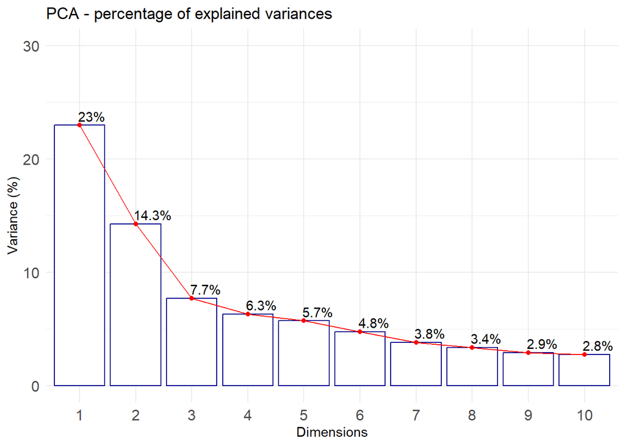

```r
p1 <- fviz_eig(mv,
                addlabels=TRUE,
                hjust = 0.05,
                barfill="white",
                barcolor ="darkblue",
                linecolor ="red") +
  ylim(0, 30) +
  labs(
    title = "PCA - percentage of explained variances",
    y = "Variance (%)") +
  theme_minimal()  +
  theme(
    axis.text.x = element_text(size = 12)
    , axis.text.y = element_text(size = 12)
  )

p1
```

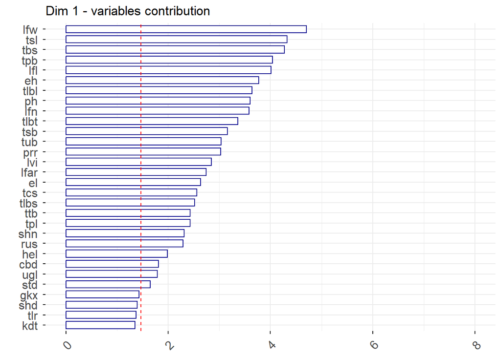

```r
p2 <- fviz_contrib(mv,
                     choice = "var",
                     axes = 1,
                     top = 30,
                     fill="white",
                     color ="darkblue"
                   , sort.val = "asc"
                   ) +
  ylim(0, 8) +
  labs(title = "Dim 1 - variables contribution", x = "") +
  coord_flip()  +
  theme(
    axis.text.x = element_text(size = 12)
    , axis.text.y = element_text(size = 12)
  )

p2
```

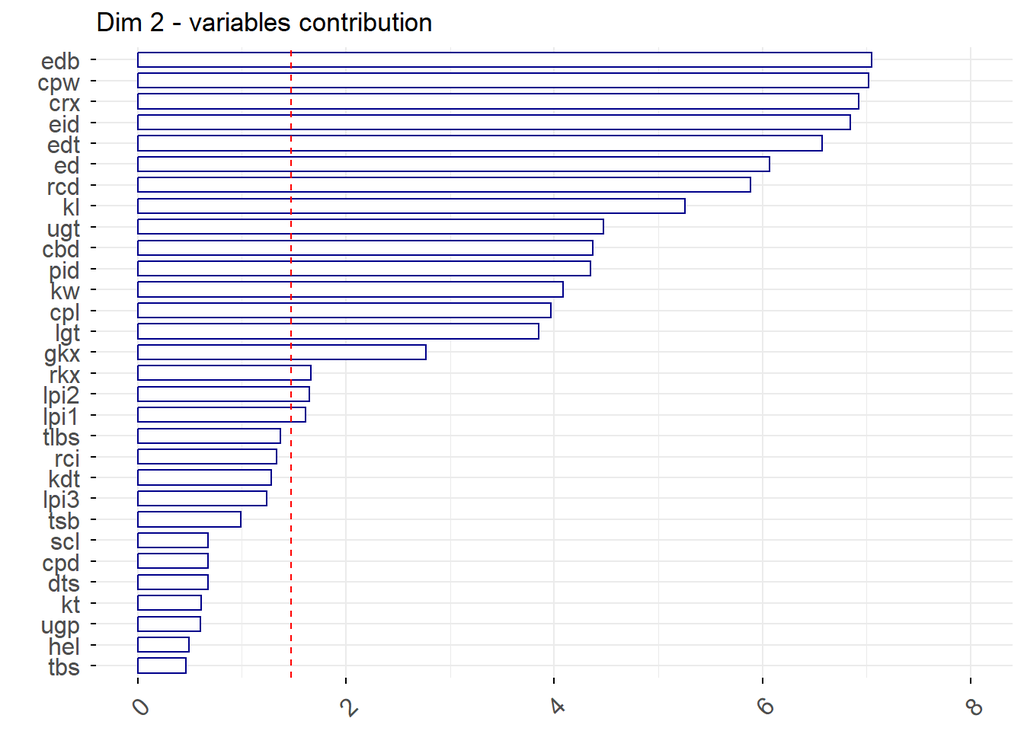

```r
p3 <- fviz_contrib(mv,
                     choice = "var",
                     axes = 2,
                     top = 30,
                     fill="white",
                     color ="darkblue"
                   , sort.val = "asc"
                   ) +
  ylim(0, 8) +
  labs(title = "Dim 2 - variables contribution", x = "") +
  coord_flip()  +
  theme(
    axis.text.x = element_text(size = 12)
    , axis.text.y = element_text(size = 12)
  )

p3
```

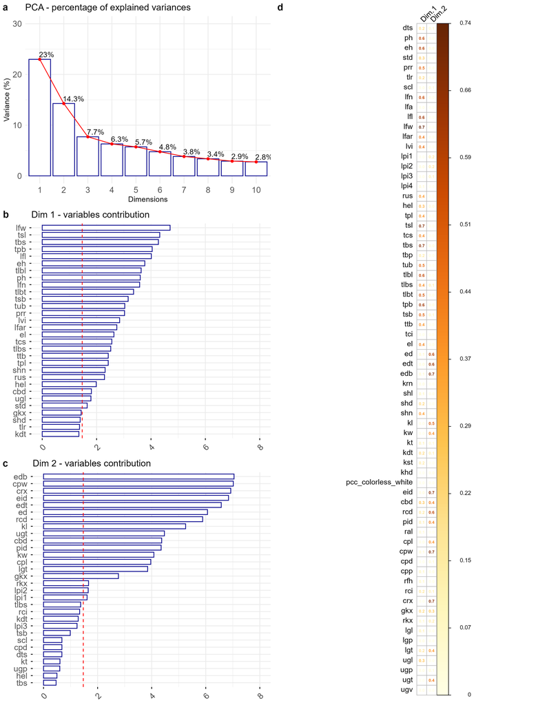

```r
panel_a <- c(p1, p2, p3) %>%
  plot_grid(plotlist = ., ncol = 1, labels = "auto", rel_heights = c(1, 1.2, 1.2))

p4 <- \() {

pcainfo$cos2[, 1:2] %>%
  corrplot(
    is.corr = F
    , method = "number",
    type = "full",
    tl.col = "black",
    tl.srt = 45,
    tl.cex = 0.9,
    number.cex = 0.5,
    number.digits = 1,
    cl.cex = 0.7,
    cl.pos = "r",
    cl.align = "r",
    cl.ratio = 4
  )

}

grid <- c(panel_a, p4) %>%
  plot_grid(plotlist = ., ncol = 2, labels = c("", "d"))

plot <- grid %>%
  ggsave(plot = ., "manuscript/Figure-1.jpg"
         , units = "cm"
         , width = 28, height = 36)

plot %>% include_graphics()
```

# 6 Descriptors with most to phenotypic differentiation

```r
# ============================================================
# 1. Datos de PCA
# ============================================================

contrib <- pcainfo$contrib %>%
  as.data.frame() %>%
  rownames_to_column("variable")

cos2 <- pcainfo$cos2 %>%
  as.data.frame() %>%
  rownames_to_column("variable")

# ============================================================
# 2. Selección inicial de variables
# ============================================================

n_traits <- length(active_traits)

expected_contrib <- 100 / n_traits

contrib_selected <- contrib %>%
  dplyr::select(variable, Dim.1, Dim.2) %>%
  pivot_longer(!c(variable)) %>%
  dplyr::filter(value > expected_contrib) %>%
  rename(contribution = value)

cos_selected <- cos2 %>%
  dplyr::select(variable, Dim.1, Dim.2) %>%
  pivot_longer(!c(variable)) %>%
  dplyr::filter(value > 0.6) %>%
  rename(cos2 = value)

selection_table <- merge(contrib_selected, cos_selected)


selection_table %>% kable()
```

| variable | name | contribution | cos2 |
| --- | --- | --- | --- |
| cpw | Dim.2 | 7.018944 | 0.6811076 |
| crx | Dim.2 | 6.925033 | 0.6719946 |
| edb | Dim.2 | 7.046391 | 0.6837710 |
| edt | Dim.2 | 6.573872 | 0.6379185 |
| eid | Dim.2 | 6.841519 | 0.6638906 |
| lfl | Dim.1 | 4.012491 | 0.6271834 |
| lfw | Dim.1 | 4.703016 | 0.7351176 |
| tbs | Dim.1 | 4.272686 | 0.6678538 |
| tpb | Dim.1 | 4.044204 | 0.6321403 |
| tsl | Dim.1 | 4.322151 | 0.6755855 |

```r
selected_traits <- selection_table %>%
  pluck(1) %>%
  unique()

table2 <- merge(selection_table, stable2, by = "variable") %>%
  dplyr::select(Category, Trait, variable, Unit:Max, everything()) %>%
  rename(Dimension = name)

table2 %>% kable()
```

| Category | Trait | variable | Unit | Mean | SD | Min | Max | Dimension | contribution | cos2 |
| --- | --- | --- | --- | --- | --- | --- | --- | --- | --- | --- |
| Ear (internal) | Cupule width | cpw | mm | 7.707692 | 2.3054152 | 2.90 | 11.50 | Dim.2 | 7.018944 | 0.6811076 |
| Ear (internal) | Cob/rachis index | crx | ratio | 1.662308 | 0.2033465 | 1.40 | 2.30 | Dim.2 | 6.925033 | 0.6719946 |
| Ear (external) | Ear base diameter | edb | cm | 4.443415 | 0.7906978 | 2.69 | 5.97 | Dim.2 | 7.046391 | 0.6837710 |
| Ear (external) | Ear tip diameter | edt | cm | 3.510732 | 0.6287901 | 2.01 | 5.28 | Dim.2 | 6.573872 | 0.6379185 |
| Ear (internal) | Ear diameter (internal ear sample) | eid | mm | 43.839474 | 7.3401723 | 26.30 | 58.00 | Dim.2 | 6.841519 | 0.6638906 |
| Leaf | Leaf length | lfl | cm | 69.332558 | 14.4302216 | 36.20 | 94.40 | Dim.1 | 4.012491 | 0.6271834 |
| Leaf | Leaf width | lfw | cm | 8.486047 | 1.2768230 | 5.70 | 10.60 | Dim.1 | 4.703016 | 0.7351176 |
| Tassel | Tassel branching space | tbs | cm | 13.802439 | 3.6356215 | 4.40 | 20.80 | Dim.1 | 4.272686 | 0.6678538 |
| Tassel | Primary tassel branches | tpb | count | 16.668293 | 5.1354376 | 5.90 | 25.80 | Dim.1 | 4.044204 | 0.6321403 |
| Tassel | Tassel length | tsl | cm | 33.237500 | 6.8946909 | 18.70 | 46.20 | Dim.1 | 4.322151 | 0.6755855 |

```r
# table2 %>% range_write(gs, .,  "Table2")
```

## 6.1 RO 2

```r
dtsl <- fb %>%
  dplyr::select(race, group, {{selected_traits}})

mv <- dtsl %>%
  column_to_rownames("race") %>%
  mutate(across(group, ~ as.factor(.))) %>%
  PCA(X = ., scale.unit = T, graph = F, quali.sup = c(1))

pcainfo <- factoextra::get_pca(mv); pcainfo
```

```
Principal Component Analysis Results for variables
 ===================================================
  Name       Description
1 "$coord"   "Coordinates for the variables"
2 "$cor"     "Correlations between variables and dimensions"
3 "$cos2"    "Cos2 for the variables"
4 "$contrib" "contributions of the variables"
```

```r
pcainfo$cor %>% kable(caption = "Variable correlations")
```

Variable correlations

|  | Dim.1 | Dim.2 | Dim.3 | Dim.4 | Dim.5 |
| --- | --- | --- | --- | --- | --- |
| cpw | 0.6872434 | -0.4746534 | -0.4276896 | 0.1275490 | 0.0752121 |
| crx | -0.6096120 | 0.5569689 | 0.3612658 | 0.1178975 | 0.3757640 |
| edb | 0.7641915 | -0.5281636 | 0.2767342 | 0.0377316 | 0.0647846 |
| edt | 0.7105304 | -0.5554793 | 0.2797980 | 0.0594900 | 0.0533441 |
| eid | 0.7272565 | -0.5660571 | 0.2023913 | 0.0117863 | 0.0988875 |
| lfl | 0.6395602 | 0.5744179 | -0.1154088 | -0.3725812 | 0.1780631 |
| lfw | 0.6915266 | 0.5668708 | -0.1158616 | -0.2926370 | 0.1247603 |
| tbs | 0.5414190 | 0.7411453 | 0.1030968 | 0.2857874 | -0.0912245 |
| tpb | 0.5607584 | 0.6689495 | 0.2987953 | -0.0961113 | -0.3165729 |
| tsl | 0.5380724 | 0.6317717 | -0.2095494 | 0.4541361 | 0.0832763 |

```r
pcainfo$contrib %>% kable(caption = "Variable Contribution")
```

Variable Contribution

|  | Dim.1 | Dim.2 | Dim.3 | Dim.4 | Dim.5 |
| --- | --- | --- | --- | --- | --- |
| cpw | 11.123421 | 6.454233 | 26.906729 | 2.9214352 | 1.7329821 |
| crx | 8.752341 | 8.886960 | 19.198055 | 2.4960404 | 43.2562338 |
| edb | 13.753766 | 7.991500 | 11.264947 | 0.2556547 | 1.2857679 |
| edt | 11.890020 | 8.839490 | 11.515765 | 0.6355226 | 0.8717497 |
| eid | 12.456398 | 9.179349 | 6.025417 | 0.0249457 | 2.9957170 |
| lfl | 9.633411 | 9.452513 | 1.959211 | 24.9278271 | 9.7132856 |
| lfw | 11.262505 | 9.205758 | 1.974617 | 15.3780354 | 4.7683802 |
| tbs | 6.903736 | 15.736135 | 1.563486 | 14.6665677 | 2.5494221 |
| tpb | 7.405747 | 12.819704 | 13.132607 | 1.6587901 | 30.7019411 |
| tsl | 6.818655 | 11.434357 | 6.459166 | 37.0351810 | 2.1245205 |

```r
pcainfo$cos2 %>% kable(caption = "Variable Cos2")
```

Variable Cos2

|  | Dim.1 | Dim.2 | Dim.3 | Dim.4 | Dim.5 |
| --- | --- | --- | --- | --- | --- |
| cpw | 0.4723035 | 0.2252959 | 0.1829184 | 0.0162687 | 0.0056569 |
| crx | 0.3716267 | 0.3102143 | 0.1305130 | 0.0138998 | 0.1411986 |
| edb | 0.5839886 | 0.2789568 | 0.0765818 | 0.0014237 | 0.0041971 |
| edt | 0.5048535 | 0.3085573 | 0.0782869 | 0.0035391 | 0.0028456 |
| eid | 0.5289020 | 0.3204206 | 0.0409622 | 0.0001389 | 0.0097787 |
| lfl | 0.4090372 | 0.3299559 | 0.0133192 | 0.1388168 | 0.0317065 |
| lfw | 0.4782090 | 0.3213425 | 0.0134239 | 0.0856364 | 0.0155651 |
| tbs | 0.2931345 | 0.5492963 | 0.0106290 | 0.0816744 | 0.0083219 |
| tpb | 0.3144500 | 0.4474934 | 0.0892786 | 0.0092374 | 0.1002184 |
| tsl | 0.2895219 | 0.3991355 | 0.0439110 | 0.2062396 | 0.0069349 |

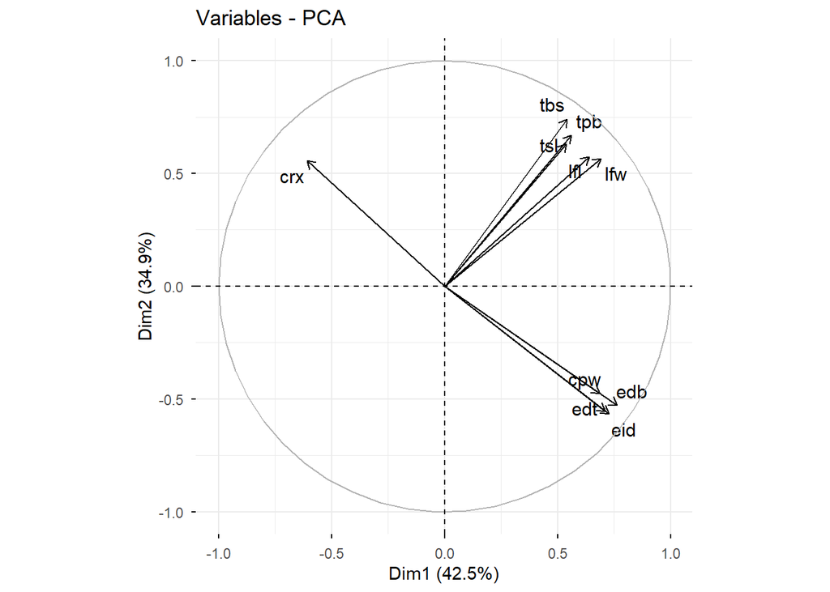

```r
var <- fviz_pca_var(mv
                    , repel = TRUE
                    , labelsize = 4
                    )

var
```

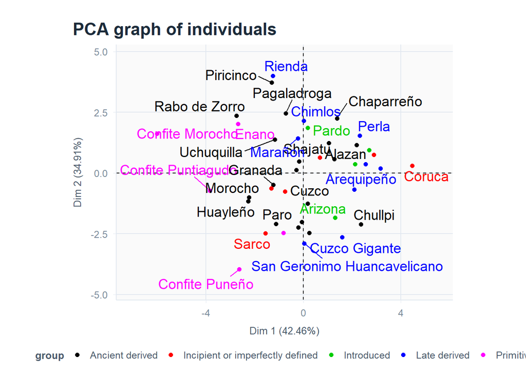

```r
ind <- plot.PCA(mv, choix = c("ind")
                , cex = 1.2
                , label = "ind"
                , invisible = "quali"
                , habillage = 1
                )  +
  theme(
    legend.position = "bottom",       # leyenda abajo
    legend.direction = "horizontal"   # en una sola línea
  ) + guides(color = guide_legend(nrow = 1))

ind
```

```r
cls <- HCPC(mv, graph = F, nb.clust = -1)

cls$call$t$tree
```

```
Call:
flashClust::hclust(d = dissi, method = method, members = weight)

Cluster method   : ward
Distance         : euclidean
Number of objects: 43
```

```r
cls$data.clust %>% kable(caption = "Cluster membership of each individual")
```

Cluster membership of each individual

|  | group | cpw | crx | edb | edt | eid | lfl | lfw | tbs | tpb | tsl | clust |
| --- | --- | --- | --- | --- | --- | --- | --- | --- | --- | --- | --- | --- |
| Confite Morocho | Primitive | 2.900000 | 2.300000 | 2.690000 | 2.170000 | 26.30000 | 53.4 | 6.3 | 9.40000 | 10.70000 | 28.7000 | 1 |
| Confite Puntiagudo | Primitive | 5.100000 | 1.710000 | 3.340000 | 2.870000 | 33.50000 | 56.2 | 6.5 | 9.10000 | 9.00000 | 24.7000 | 1 |
| Kculli | Primitive | 8.100000 | 1.400000 | 4.710000 | 3.380000 | 46.90000 | 58.0 | 7.4 | 8.80000 | 10.30000 | 27.2000 | 2 |
| Confite Puneño | Primitive | 7.400000 | 1.540000 | 4.460000 | 3.800000 | 44.50000 | 52.3 | 5.7 | 4.40000 | 5.90000 | 18.7000 | 2 |
| Enano | Primitive | 3.700000 | 1.830000 | 2.700000 | 2.010000 | 43.83947 | 73.7 | 7.7 | 13.80244 | 16.66829 | 33.2375 | 1 |
| Huayleño | Ancient derived | 5.300000 | 1.840000 | 4.200000 | 3.600000 | 42.00000 | 61.6 | 7.7 | 8.20000 | 14.90000 | 19.1000 | 2 |
| Chullpi | Ancient derived | 7.100000 | 1.600000 | 5.860000 | 5.280000 | 58.00000 | 72.0 | 8.2 | 14.60000 | 18.00000 | 28.5000 | 2 |
| Granada | Ancient derived | 6.900000 | 1.740000 | 4.180000 | 3.500000 | 42.60000 | 66.6 | 6.9 | 13.60000 | 15.20000 | 27.7000 | 2 |
| Paro | Ancient derived | 7.500000 | 1.460000 | 4.670000 | 3.640000 | 43.30000 | 36.2 | 6.9 | 12.00000 | 11.50000 | 33.0000 | 2 |
| Morocho | Ancient derived | 8.200000 | 1.690000 | 3.730000 | 3.050000 | 37.30000 | 59.0 | 8.7 | 7.80000 | 9.90000 | 24.8000 | 2 |
| Huancavelicano | Ancient derived | 10.800000 | 1.580000 | 4.700000 | 3.650000 | 46.50000 | 55.1 | 8.3 | 9.20000 | 11.80000 | 28.7000 | 2 |
| Mochero | Ancient derived | 7.900000 | 1.540000 | 4.060000 | 3.730000 | 41.30000 | 75.8 | 8.8 | 16.80000 | 23.60000 | 37.9000 | 3 |
| Pagaladroga | Ancient derived | 5.900000 | 1.740000 | 3.700000 | 2.750000 | 34.90000 | 76.2 | 9.7 | 16.20000 | 21.50000 | 33.7000 | 1 |
| Chaparreño | Ancient derived | 6.500000 | 1.650000 | 4.280000 | 3.650000 | 41.10000 | 90.2 | 9.2 | 15.80000 | 25.80000 | 43.1000 | 3 |
| Rabo de Zorro | Ancient derived | 4.600000 | 2.170000 | 3.500000 | 2.600000 | 34.80000 | 61.1 | 8.7 | 15.60000 | 16.00000 | 32.8000 | 1 |
| Piricinco | Ancient derived | 4.100000 | 1.880000 | 3.630000 | 2.480000 | 30.50000 | 77.9 | 9.3 | 17.90000 | 25.00000 | 35.5000 | 1 |
| Ancashino | Ancient derived | 6.700000 | 1.460000 | 5.280000 | 3.620000 | 49.50000 | 55.9 | 8.2 | 10.60000 | 15.70000 | 25.2000 | 2 |
| Shajatu | Ancient derived | 6.200000 | 1.720000 | 4.500000 | 3.600000 | 44.00000 | 63.5 | 7.4 | 16.90000 | 18.80000 | 36.4000 | 3 |
| Alazan | Ancient derived | 10.300000 | 1.560000 | 4.300000 | 3.950000 | 42.80000 | 87.2 | 9.9 | 16.60000 | 23.60000 | 36.9000 | 3 |
| Sabanero | Ancient derived | 10.100000 | 1.530000 | 4.630000 | 3.220000 | 42.20000 | 86.7 | 9.5 | 16.30000 | 16.30000 | 34.1000 | 3 |
| Uchuquilla | Ancient derived | 8.600000 | 1.640000 | 3.290000 | 2.860000 | 33.80000 | 58.7 | 7.7 | 16.50000 | 17.50000 | 40.5000 | 1 |
| Cuzco Cristalino Amarillo | Ancient derived | 8.400000 | 1.520000 | 3.840000 | 3.230000 | 40.10000 | 73.8 | 9.4 | 13.90000 | 12.60000 | 30.8000 | 3 |
| Cuzco | Ancient derived | 9.800000 | 1.660000 | 4.600000 | 3.770000 | 46.50000 | 64.3 | 8.9 | 11.90000 | 12.90000 | 29.3000 | 2 |
| Pisccorunto | Ancient derived | 8.500000 | 1.520000 | 4.970000 | 4.000000 | 51.50000 | 76.2 | 7.4 | 8.30000 | 7.80000 | 33.2375 | 2 |
| Arequipeño | Late derived | 10.000000 | 1.470000 | 5.370000 | 3.550000 | 51.70000 | 81.0 | 9.1 | 15.10000 | 18.40000 | 32.0000 | 3 |
| Huachano | Late derived | 9.600000 | 1.610000 | 5.000000 | 4.140000 | 50.10000 | 81.9 | 9.5 | 17.40000 | 19.20000 | 40.2000 | 3 |
| Chancayano | Late derived | 11.500000 | 1.560000 | 5.110000 | 4.150000 | 49.40000 | 87.0 | 10.2 | 15.40000 | 18.80000 | 42.4000 | 3 |
| San Geronimo Huancavelicano | Late derived | 9.900000 | 1.550000 | 5.200000 | 4.100000 | 49.30000 | 55.1 | 6.6 | 11.60000 | 15.00000 | 23.2000 | 2 |
| Perla | Late derived | 9.200000 | 1.630000 | 4.740000 | 3.600000 | 45.00000 | 94.4 | 10.6 | 16.50000 | 20.80000 | 39.3000 | 3 |
| Rienda | Late derived | 4.100000 | 2.170000 | 3.620000 | 2.860000 | 34.70000 | 70.6 | 9.1 | 20.80000 | 20.50000 | 43.3000 | 1 |
| Marañon | Late derived | 5.700000 | 1.730000 | 4.330000 | 3.070000 | 41.20000 | 76.0 | 9.1 | 15.00000 | 18.60000 | 36.2000 | 3 |
| Chimlos | Late derived | 4.500000 | 1.890000 | 4.510000 | 3.290000 | 41.80000 | 76.9 | 9.7 | 15.80000 | 23.70000 | 34.2000 | 3 |
| Cuzco Gigante | Late derived | 11.200000 | 1.680000 | 5.930000 | 4.270000 | 56.80000 | 51.8 | 7.6 | 13.80000 | 12.30000 | 36.0000 | 2 |
| Pardo | Introduced | 7.900000 | 1.710000 | 3.830000 | 3.200000 | 38.60000 | 81.3 | 8.9 | 17.70000 | 12.90000 | 46.2000 | 3 |
| Aleman | Introduced | 8.500000 | 1.560000 | 4.980000 | 4.070000 | 46.90000 | 85.3 | 9.7 | 15.20000 | 20.40000 | 36.4000 | 3 |
| Chuncho | Introduced | 7.500000 | 1.620000 | 5.210000 | 4.200000 | 49.50000 | 82.4 | 10.5 | 16.90000 | 24.90000 | 36.0000 | 3 |
| Arizona | Introduced | 10.900000 | 1.480000 | 5.070000 | 4.040000 | 49.90000 | 55.9 | 8.2 | 12.10000 | 16.50000 | 36.1000 | 2 |
| Jora | Incipient or imperfectly defined | 9.200000 | 1.430000 | 4.860000 | 3.840000 | 50.10000 | 83.2 | 9.9 | 17.20000 | 21.10000 | 43.6000 | 3 |
| Coruca | Incipient or imperfectly defined | 10.300000 | 1.460000 | 5.970000 | 4.070000 | 57.00000 | 91.0 | 10.4 | 19.20000 | 23.80000 | 39.0000 | 3 |
| Morocho Cajabambino | Incipient or imperfectly defined | 7.707692 | 1.662308 | 3.840000 | 3.200000 | 43.83947 | 58.1 | 7.9 | 11.50000 | 15.80000 | 27.4000 | 2 |
| Morado Canteño | Incipient or imperfectly defined | 7.707692 | 1.662308 | 4.443415 | 3.510732 | 43.83947 | 53.5 | 7.2 | 13.30000 | 12.80000 | 37.6000 | 2 |
| Sarco | Incipient or imperfectly defined | 7.707692 | 1.662308 | 4.790000 | 3.880000 | 43.83947 | 40.3 | 6.5 | 11.00000 | 13.60000 | 23.1000 | 2 |
| Perlilla | Incipient or imperfectly defined | 7.707692 | 1.662308 | 4.443415 | 3.510732 | 43.83947 | 84.0 | 9.8 | 13.80244 | 16.66829 | 33.2375 | 3 |

```r
cls$desc.var$quanti %>% kable(caption = "Quantitative variables characterizing each cluster")
```

Quantitative variables characterizing each cluster

|  | v.test | Mean in category | Overall mean | sd in category | Overall sd | p.value | n |
| --- | --- | --- | --- | --- | --- | --- | --- |
| crx | 4.338876 | 1.93000 | 1.662308 | 0.2327015 | 0.1911588 | 0.0000143 | 8 |
| cpw | -4.049751 | 4.87500 | 7.707692 | 1.6406935 | 2.1672386 | 0.0000513 | 8 |
| eid | -4.458180 | 34.04243 | 43.839474 | 4.6175052 | 6.8088362 | 0.0000083 | 8 |
| edb | -4.609957 | 3.30875 | 4.443415 | 0.3782340 | 0.7626167 | 0.0000040 | 8 |
| edt | -4.780634 | 2.57500 | 3.510732 | 0.3108456 | 0.6064590 | 0.0000017 | 8 |

|  | v.test | Mean in category | Overall mean | sd in category | Overall sd | p.value | n |
| --- | --- | --- | --- | --- | --- | --- | --- |
| edt | 2.342352 | 3.781808 | 3.510732 | 0.4846861 | 0.6064590 | 0.0191626 | 17 |
| eid | 2.302020 | 46.830495 | 43.839474 | 5.1198480 | 6.8088362 | 0.0213340 | 17 |
| edb | 2.059598 | 4.743142 | 4.443415 | 0.5924275 | 0.7626167 | 0.0394369 | 17 |
| lfw | -3.899431 | 7.547059 | 8.486047 | 0.8247050 | 1.2618888 | 0.0000964 | 17 |
| tpb | -3.949545 | 12.935294 | 16.668293 | 3.1031182 | 4.9530559 | 0.0000783 | 17 |
| tsl | -4.046764 | 28.166912 | 33.237500 | 5.4668939 | 6.5661814 | 0.0000519 | 17 |
| lfl | -4.468924 | 57.170588 | 69.332558 | 9.5440628 | 14.2614413 | 0.0000079 | 17 |
| tbs | -4.566182 | 10.747059 | 13.802439 | 2.5731916 | 3.5065048 | 0.0000050 | 17 |

|  | v.test | Mean in category | Overall mean | sd in category | Overall sd | p.value | n |
| --- | --- | --- | --- | --- | --- | --- | --- |
| lfl | 5.004420 | 82.311111 | 69.332558 | 7.0801670 | 14.261441 | 0.0000006 | 18 |
| lfw | 4.563893 | 9.533333 | 8.486047 | 0.7325754 | 1.261889 | 0.0000050 | 18 |
| tbs | 3.751485 | 16.194580 | 13.802439 | 1.3110168 | 3.506505 | 0.0001758 | 18 |
| tsl | 3.706461 | 37.663194 | 33.237500 | 4.1042628 | 6.566181 | 0.0002102 | 18 |
| tpb | 3.697046 | 19.998238 | 16.668293 | 3.7395054 | 4.953056 | 0.0002181 | 18 |

```r
cls$desc.var$category%>% kable(caption = "Categorical variables significantly by cluster")
```

Categorical variables significantly by cluster

|  | Cla/Mod | Mod/Cla | Global | p.value | v.test |
| --- | --- | --- | --- | --- | --- |
| group=Primitive | 60 | 37.5 | 11.62791 | 0.0398214 | 2.055597 |

```r
table(cls$data.clust$clust) %>% kable(caption = "Number of individuals assigned to each cluster")
```

Number of individuals assigned to each cluster

| Var1 | Freq |
| --- | --- |
| 1 | 8 |
| 2 | 17 |
| 3 | 18 |

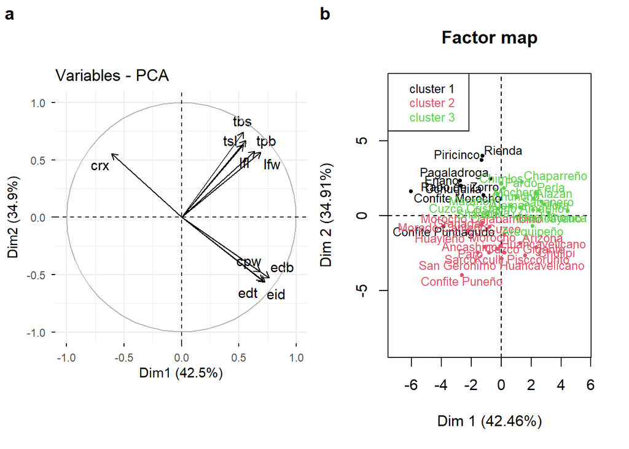

```r
clsp <- function() {

  plot.HCPC(cls, choice = "map", draw.tree = F)

}

grid <- plot_grid(plotlist = list(var, clsp)
                  , ncol = 2, labels = "auto")

grid
```

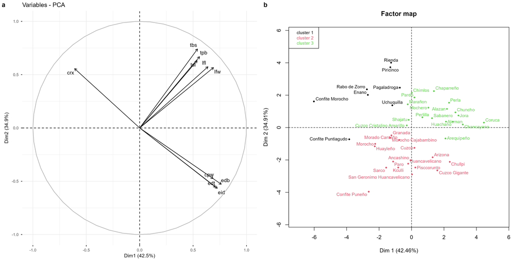

```r
plot <- grid %>%
  ggsave(plot = ., "manuscript/Figure-2.jpg", units = "cm"
                , width = 40, height = 20)

plot %>% include_graphics()
```

## 6.2 RO 3

Comparar con la clasificación de Grobman et al. 1961 (Table 8, Pag. 139):

Grobman, Alexander; Wilfredo Salhuana, Ricardo Sevilla y Paul C. Mangelsdorf. 1961. Races of Maize in Peru: Their Origins, Evolution and Classification. (Publication 915). Washington, D.C.: National Academy of Sciences, National Research Council.

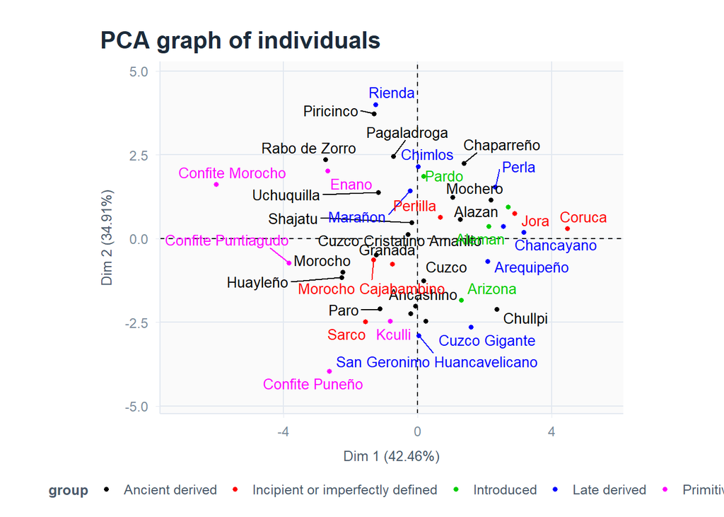

```r
ind <- plot.PCA(mv
                , choix = c("ind")
                , cex = 0.9
                , label = "ind"
                , invisible = "quali"
                , habillage = 1
                )  +
  theme(
    legend.position = "bottom",
    legend.direction = "horizontal"
  ) + guides(color = guide_legend(nrow = 1))

ind
```

```r
infoind <- mv %>%
  get_pca_ind()

infoind$coord %>% kable(caption = "Coordinates for the individuals")
```

Coordinates for the individuals

|  | Dim.1 | Dim.2 | Dim.3 | Dim.4 | Dim.5 |
| --- | --- | --- | --- | --- | --- |
| Confite Morocho | -6.0172960 | 1.6135180 | 0.4399022 | 0.3056476 | 1.0299526 |
| Confite Puntiagudo | -3.8391499 | -0.7233410 | -0.5316760 | -0.3761206 | -0.2680650 |
| Kculli | -0.8200223 | -2.4686002 | -0.7190903 | -0.3843413 | -0.4107607 |
| Confite Puneño | -2.6372332 | -3.9598541 | -0.0967653 | -0.7168622 | 0.0800290 |
| Enano | -2.6913754 | 2.0184532 | -0.2187799 | -0.3989660 | -0.1973285 |
| Huayleño | -2.2650048 | -1.1577130 | 1.2415362 | -1.4129042 | 0.2299967 |
| Chullpi | 2.3582826 | -2.1172716 | 2.4415106 | -0.1311741 | 0.3100283 |
| Granada | -1.2403174 | -0.4805731 | 0.5079001 | 0.0701541 | -0.1377062 |
| Paro | -1.1344886 | -2.0998802 | -0.1928076 | 1.4155230 | -1.0123375 |
| Morocho | -2.2401254 | -1.0073519 | -1.1669770 | -1.0276514 | 0.4363476 |
| Huancavelicano | -0.2068936 | -2.2304468 | -0.8262901 | -0.0231911 | 0.3421056 |
| Mochero | 1.0405938 | 1.2295653 | -0.1288260 | 0.1668784 | -1.1097057 |
| Pagaladroga | -0.7200401 | 2.4636245 | -0.2458746 | -0.6869725 | -0.5766716 |
| Chaparreño | 1.3785492 | 2.2520984 | 0.2413953 | -0.1619274 | -0.5022092 |
| Rabo de Zorro | -2.7508216 | 2.3609417 | 0.7459109 | 0.3661475 | 0.8880229 |
| Piricinco | -1.3074571 | 3.7255542 | 0.4402120 | -0.4372885 | -0.8292150 |
| Ancashino | -0.0608187 | -2.0174892 | 0.7006195 | -0.6740751 | -0.7394788 |
| Shajatu | -0.1754842 | 0.4753418 | 0.8959368 | 1.0623099 | -0.4915653 |
| Alazan | 2.1844213 | 1.1519768 | -0.5774130 | -0.4344682 | -0.3610379 |
| Sabanero | 1.2622141 | 0.5780950 | -1.2701542 | -0.5111504 | 0.1330278 |
| Uchuquilla | -1.1832526 | 1.3750003 | -1.4305522 | 1.4292384 | -0.9724797 |
| Cuzco Cristalino Amarillo | -0.2929721 | 0.1321021 | -1.3948037 | -0.6984906 | -0.0232141 |
| Cuzco | 0.1814109 | -1.2517609 | -0.3840129 | -0.2134436 | 0.6324127 |
| Pisccorunto | 0.2345869 | -2.4673743 | -0.5256413 | -0.2114063 | 1.1116419 |
| Arequipeño | 2.0911263 | -0.6737192 | -0.2383017 | -0.5105894 | -0.0978377 |
| Huachano | 2.5538590 | 0.3664971 | 0.0577330 | 0.4574582 | 0.4313780 |
| Chancayano | 3.1593330 | 0.1876453 | -0.7965980 | 0.1727517 | 0.7921002 |
| San Geronimo Huancavelicano | 0.0299994 | -2.8914350 | 0.6150544 | 0.1772919 | -0.4845146 |
| Perla | 2.3127847 | 1.5340800 | -0.5265093 | -0.6603753 | 0.5299879 |
| Rienda | -1.2591767 | 4.0073353 | 1.0307529 | 1.3357991 | 0.6826952 |
| Marañon | -0.2342207 | 1.4355102 | 0.1795664 | -0.2430503 | 0.0062186 |
| Chimlos | 0.0169849 | 2.1442633 | 1.4609009 | -0.6117790 | 0.0318449 |
| Cuzco Gigante | 1.5889523 | -2.6465802 | 0.5951702 | 1.7769826 | 0.9540259 |
| Pardo | 0.1802667 | 1.8582933 | -1.3714413 | 1.1383584 | 0.7685222 |
| Aleman | 2.1237089 | 0.3651442 | 0.1438593 | -0.4934236 | 0.0879307 |
| Chuncho | 2.7058599 | 0.9381051 | 1.1331518 | -0.5998339 | -0.1607094 |
| Arizona | 1.3018096 | -1.8356404 | -0.4116454 | 0.8691613 | -0.2877830 |
| Jora | 2.8915098 | 0.7456654 | -0.5456106 | 0.3024803 | -0.3095657 |
| Coruca | 4.4605928 | 0.3051711 | 0.4405207 | -0.1727002 | -0.0019283 |
| Morocho Cajabambino | -1.3228123 | -0.6309111 | -0.1836214 | -0.2754086 | -0.4120478 |
| Morado Canteño | -0.7632863 | -0.7623481 | -0.1711902 | 1.4039730 | -0.0160822 |
| Sarco | -1.5632533 | -2.4738222 | 0.9332245 | 0.5392576 | -0.6239349 |
| Perlilla | 0.6686563 | 0.6321304 | -0.2902755 | -0.9218195 | 0.5479098 |

```r
infoind$cos2 %>% kable(caption = "Cos2 for the individuals")
```

Cos2 for the individuals

|  | Dim.1 | Dim.2 | Dim.3 | Dim.4 | Dim.5 |
| --- | --- | --- | --- | --- | --- |
| Confite Morocho | 0.8915126 | 0.0641021 | 0.0047647 | 0.0023002 | 0.0261192 |
| Confite Puntiagudo | 0.9077686 | 0.0322249 | 0.0174100 | 0.0087128 | 0.0044257 |
| Kculli | 0.0820810 | 0.7438631 | 0.0631188 | 0.0180312 | 0.0205954 |
| Confite Puneño | 0.2923956 | 0.6592228 | 0.0003937 | 0.0216045 | 0.0002693 |
| Enano | 0.4521328 | 0.2543050 | 0.0029877 | 0.0099355 | 0.0024305 |
| Huayleño | 0.4984333 | 0.1302179 | 0.1497572 | 0.1939520 | 0.0051394 |
| Chullpi | 0.3232942 | 0.2605909 | 0.3465161 | 0.0010002 | 0.0055874 |
| Granada | 0.5349556 | 0.0803103 | 0.0897033 | 0.0017114 | 0.0065941 |
| Paro | 0.1340596 | 0.4592897 | 0.0038721 | 0.2087044 | 0.1067452 |
| Morocho | 0.5310371 | 0.1073847 | 0.1441135 | 0.1117563 | 0.0201486 |
| Huancavelicano | 0.0063660 | 0.7398760 | 0.1015407 | 0.0000800 | 0.0174059 |
| Mochero | 0.2460467 | 0.3435249 | 0.0037710 | 0.0063278 | 0.2798148 |
| Pagaladroga | 0.0674211 | 0.7892808 | 0.0078616 | 0.0613707 | 0.0432454 |
| Chaparreño | 0.2107827 | 0.5625552 | 0.0064632 | 0.0029082 | 0.0279743 |
| Rabo de Zorro | 0.4944052 | 0.3641906 | 0.0363523 | 0.0087593 | 0.0515236 |
| Piricinco | 0.1004184 | 0.8153425 | 0.0113837 | 0.0112330 | 0.0403917 |
| Ancashino | 0.0005628 | 0.6192934 | 0.0746859 | 0.0691338 | 0.0832004 |
| Shajatu | 0.0113704 | 0.0834284 | 0.2963851 | 0.4166814 | 0.0892204 |
| Alazan | 0.5940983 | 0.1652240 | 0.0415106 | 0.0235018 | 0.0162290 |
| Sabanero | 0.3386904 | 0.0710453 | 0.3429650 | 0.0555436 | 0.0037620 |
| Uchuquilla | 0.1631184 | 0.2202691 | 0.2384269 | 0.2379892 | 0.1101816 |
| Cuzco Cristalino Amarillo | 0.0265395 | 0.0053958 | 0.6015425 | 0.1508555 | 0.0001666 |
| Cuzco | 0.0118607 | 0.5647102 | 0.0531465 | 0.0164191 | 0.1441399 |
| Pisccorunto | 0.0056604 | 0.6261941 | 0.0284196 | 0.0045970 | 0.1271068 |
| Arequipeño | 0.7116357 | 0.0738678 | 0.0092417 | 0.0424268 | 0.0015578 |
| Huachano | 0.9118891 | 0.0187797 | 0.0004660 | 0.0292584 | 0.0260174 |
| Chancayano | 0.8597298 | 0.0030328 | 0.0546575 | 0.0025705 | 0.0540420 |
| San Geronimo Huancavelicano | 0.0000899 | 0.8348219 | 0.0377741 | 0.0031387 | 0.0234412 |
| Perla | 0.6119593 | 0.2692453 | 0.0317150 | 0.0498923 | 0.0321354 |
| Rienda | 0.0750810 | 0.7604457 | 0.0503113 | 0.0844966 | 0.0220704 |
| Marañon | 0.0210052 | 0.7890223 | 0.0123460 | 0.0226188 | 0.0000148 |
| Chimlos | 0.0000389 | 0.6206851 | 0.2881088 | 0.0505247 | 0.0001369 |
| Cuzco Gigante | 0.1734648 | 0.4812378 | 0.0243373 | 0.2169481 | 0.0625331 |
| Pardo | 0.0040143 | 0.4265883 | 0.2323458 | 0.1600805 | 0.0729614 |
| Aleman | 0.8834556 | 0.0261170 | 0.0040539 | 0.0476908 | 0.0015145 |
| Chuncho | 0.7208060 | 0.0866385 | 0.1264107 | 0.0354217 | 0.0025427 |
| Arizona | 0.2539405 | 0.5049079 | 0.0253912 | 0.1131977 | 0.0124099 |
| Jora | 0.8513539 | 0.0566173 | 0.0303128 | 0.0093166 | 0.0097581 |
| Coruca | 0.9490141 | 0.0044420 | 0.0092559 | 0.0014226 | 0.0000002 |
| Morocho Cajabambino | 0.5878112 | 0.1337143 | 0.0113263 | 0.0254798 | 0.0570344 |
| Morado Canteño | 0.1742757 | 0.1738475 | 0.0087664 | 0.5896298 | 0.0000774 |
| Sarco | 0.2304417 | 0.5770843 | 0.0821248 | 0.0274217 | 0.0367097 |
| Perlilla | 0.2087339 | 0.1865522 | 0.0393376 | 0.3967152 | 0.1401539 |

```r
infoind$contrib %>% kable(caption = "contributions of the individuals")
```

contributions of the individuals

|  | Dim.1 | Dim.2 | Dim.3 | Dim.4 | Dim.5 |
| --- | --- | --- | --- | --- | --- |
| Confite Morocho | 19.8313171 | 1.7344852 | 0.6619838 | 0.3901360 | 7.5576072 |
| Confite Puntiagudo | 8.0727022 | 0.3485854 | 0.9670062 | 0.5907834 | 0.5119529 |
| Kculli | 0.3682987 | 4.0599852 | 1.7688948 | 0.6168905 | 1.2020640 |
| Confite Puneño | 3.8093061 | 10.4467526 | 0.0320313 | 2.1460774 | 0.0456294 |
| Enano | 3.9673212 | 2.7143155 | 0.1637382 | 0.6647309 | 0.2774146 |
| Huayleño | 2.8098753 | 0.8929451 | 5.2729527 | 8.3368006 | 0.3768714 |
| Chullpi | 3.0460744 | 2.9865934 | 20.3916487 | 0.0718572 | 0.6847822 |
| Granada | 0.8425865 | 0.1538657 | 0.8824531 | 0.0205533 | 0.1351004 |
| Paro | 0.7049351 | 2.9377307 | 0.1271696 | 8.3677344 | 7.3013056 |
| Morocho | 2.7484855 | 0.6760601 | 4.6586458 | 4.4102748 | 1.3564853 |
| Huancavelicano | 0.0234446 | 3.3144134 | 2.3356095 | 0.0022460 | 0.8338158 |
| Mochero | 0.5930773 | 1.0072242 | 0.0567730 | 0.1162985 | 8.7733504 |
| Pagaladroga | 0.2839633 | 4.0436354 | 0.2068057 | 1.9708459 | 2.3692289 |
| Chaparreño | 1.0408624 | 3.3790739 | 0.1993392 | 0.1095002 | 1.7968806 |
| Rabo de Zorro | 4.1445145 | 3.7135860 | 1.9033078 | 0.5598687 | 5.6182137 |
| Piricinco | 0.9362756 | 9.2470821 | 0.6629166 | 0.7985648 | 4.8987379 |
| Ancashino | 0.0020259 | 2.7117233 | 1.6791887 | 1.8975384 | 3.8958415 |
| Shajatu | 0.0168665 | 0.1505341 | 2.7459325 | 4.7127727 | 1.7215212 |
| Alazan | 2.6134945 | 0.8841184 | 1.1405339 | 0.7882972 | 0.9286575 |
| Sabanero | 0.8725992 | 0.2226493 | 5.5188429 | 1.0911173 | 0.1260766 |
| Uchuquilla | 0.7668382 | 1.2595881 | 7.0007173 | 8.5306742 | 6.7376888 |
| Cuzco Cristalino Amarillo | 0.0470112 | 0.0116263 | 6.6552028 | 2.0374883 | 0.0038393 |
| Cuzco | 0.0180250 | 1.0439163 | 0.5044600 | 0.1902568 | 2.8493845 |
| Pisccorunto | 0.0301409 | 4.0559541 | 0.9451790 | 0.1866422 | 8.8039938 |
| Arequipeño | 2.3950210 | 0.3023993 | 0.1942627 | 1.0887234 | 0.0681965 |
| Huachano | 3.5722565 | 0.0894879 | 0.0114021 | 0.8739303 | 1.3257632 |
| Chancayano | 5.4668808 | 0.0234584 | 2.1707689 | 0.1246289 | 4.4700272 |
| San Geronimo Huancavelicano | 0.0004929 | 5.5699308 | 1.2940831 | 0.1312659 | 1.6724901 |
| Perla | 2.9296733 | 1.5679021 | 0.9483033 | 1.8211917 | 2.0011599 |
| Rienda | 0.8684047 | 10.6987815 | 3.6344963 | 7.4517158 | 3.3205004 |
| Marañon | 0.0300469 | 1.3728893 | 0.1103025 | 0.2466984 | 0.0002755 |
| Chimlos | 0.0001580 | 3.0632270 | 7.3009043 | 1.5630148 | 0.0072249 |
| Cuzco Gigante | 1.3828354 | 4.6665194 | 1.2117624 | 13.1868282 | 6.4844063 |
| Pardo | 0.0177984 | 2.3006549 | 6.4341265 | 5.4116791 | 4.2078736 |
| Aleman | 2.4702380 | 0.0888284 | 0.0707964 | 1.0167491 | 0.0550847 |
| Chuncho | 4.0101390 | 0.5863081 | 4.3924954 | 1.5025746 | 0.1840062 |
| Arizona | 0.9282047 | 2.2449060 | 0.5796712 | 3.1548216 | 0.5900383 |
| Jora | 4.5792899 | 0.3704341 | 1.0183585 | 0.3820923 | 0.6827404 |
| Coruca | 10.8976775 | 0.0620454 | 0.6638466 | 0.1245546 | 0.0000265 |
| Morocho Cajabambino | 0.9583966 | 0.2651913 | 0.1153404 | 0.3167591 | 1.2096091 |
| Morado Canteño | 0.3190977 | 0.3871948 | 0.1002520 | 8.2317374 | 0.0018426 |
| Sarco | 1.3384665 | 4.0771803 | 2.9792532 | 1.2144135 | 2.7735016 |
| Perlilla | 0.2448808 | 0.2662173 | 0.2882410 | 3.5486718 | 2.1387894 |

```r
infoind$dist
```

```
            Confite Morocho          Confite Puntiagudo
                   6.372908                    4.029466
                     Kculli              Confite Puneño
                   2.862228                    4.877116
                      Enano                    Huayleño
                   4.002591                    3.208231
                    Chullpi                     Granada
                   4.147601                    1.695797
                       Paro                     Morocho
                   3.098498                    3.074043
             Huancavelicano                     Mochero
                   2.593059                    2.097841
                Pagaladroga                  Chaparreño
                   2.773057                    3.002651
              Rabo de Zorro                   Piricinco
                   3.912199                    4.125920
                  Ancashino                     Shajatu
                   2.563675                    1.645694
                     Alazan                    Sabanero
                   2.834048                    2.168860
                 Uchuquilla   Cuzco Cristalino Amarillo
                   2.929720                    1.798374
                      Cuzco                 Pisccorunto
                   1.665745                    3.118032
                 Arequipeño                    Huachano
                   2.478857                    2.674397
                 Chancayano San Geronimo Huancavelicano
                   3.407332                    3.164583
                      Perla                      Rienda
                   2.956473                    4.595382
                    Marañon                     Chimlos
                   1.616075                    2.721714
              Cuzco Gigante                       Pardo
                   3.815094                    2.845180
                     Aleman                     Chuncho
                   2.259449                    3.187103
                    Arizona                        Jora
                   2.583340                    3.133788
                     Coruca         Morocho Cajabambino
                   4.578848                    1.725358
             Morado Canteño                       Sarco
                   1.828391                    3.256483
                   Perlilla
                   1.463546
```

```r
cls <- HCPC(mv, graph = F, nb.clust = 6) # k = 6

cls$call$t
```

```
$res
**Results for the Principal Component Analysis (PCA)**
The analysis was performed on 43 individuals, described by 11 variables
*The results are available in the following objects:

   name                description
1  "$eig"              "eigenvalues"
2  "$var"              "results for the variables"
3  "$var$coord"        "coord. for the variables"
4  "$var$cor"          "correlations variables - dimensions"
5  "$var$cos2"         "cos2 for the variables"
6  "$var$contrib"      "contributions of the variables"
7  "$ind"              "results for the individuals"
8  "$ind$coord"        "coord. for the individuals"
9  "$ind$cos2"         "cos2 for the individuals"
10 "$ind$contrib"      "contributions of the individuals"
11 "$quali.sup"        "results for the supplementary categorical variables"
12 "$quali.sup$coord"  "coord. for the supplementary categories"
13 "$quali.sup$v.test" "v-test of the supplementary categories"
14 "$call"             "summary statistics"
15 "$call$centre"      "mean of the variables"
16 "$call$ecart.type"  "standard error of the variables"
17 "$call$row.w"       "weights for the individuals"
18 "$call$col.w"       "weights for the variables"

$tree

Call:
flashClust::hclust(d = dissi, method = method, members = weight)

Cluster method   : ward
Distance         : euclidean
Number of objects: 43


$nb.clust
[1] 3

$within
 [1] 9.299817706 6.576163511 4.589246176 3.792991402 3.187279289 2.824951132
 [7] 2.472718880 2.209567312 1.996781017 1.790593482 1.603126871 1.453542097
[13] 1.322163896 1.194408584 1.104621524 1.015864487 0.929289890 0.848801496
[19] 0.780659842 0.717475522 0.655745483 0.595141414 0.538989411 0.491082656
[25] 0.444903350 0.398835463 0.357962101 0.317613134 0.278555396 0.242623047
[31] 0.209892267 0.180702526 0.157320345 0.136619284 0.115991181 0.096733399
[37] 0.077982653 0.059736337 0.045071797 0.031178588 0.019434027 0.008166113

$inert.gain
 [1] 2.723654195 1.986917336 0.796254774 0.605712113 0.362328157 0.352232253
 [7] 0.263151568 0.212786295 0.206187535 0.187466611 0.149584774 0.131378202
[13] 0.127755311 0.089787060 0.088757036 0.086574597 0.080488394 0.068141653
[19] 0.063184321 0.061730039 0.060604069 0.056152004 0.047906754 0.046179307
[25] 0.046067887 0.040873362 0.040348967 0.039057738 0.035932349 0.032730780
[31] 0.029189741 0.023382181 0.020701060 0.020628103 0.019257782 0.018750747
[37] 0.018246315 0.014664540 0.013893209 0.011744561 0.011267914 0.008166113

$quot
[1] 3.0039379 0.9651726 1.8964335 0.7086289 1.2915803 1.1552663 0.8605006
[8] 0.9889309
```

```r
cls$call$X
```

```
                                  Dim.1      Dim.2       Dim.3       Dim.4
Confite Morocho             -6.01729604  1.6135180  0.43990220  0.30564761
Confite Puntiagudo          -3.83914986 -0.7233410 -0.53167601 -0.37612061
Rabo de Zorro               -2.75082163  2.3609417  0.74591091  0.36614752
Enano                       -2.69137541  2.0184532 -0.21877994 -0.39896602
Confite Puneño              -2.63723322 -3.9598541 -0.09676535 -0.71686221
Huayleño                    -2.26500476 -1.1577130  1.24153618 -1.41290415
Morocho                     -2.24012536 -1.0073519 -1.16697698 -1.02765141
Sarco                       -1.56325332 -2.4738222  0.93322454  0.53925762
Morocho Cajabambino         -1.32281233 -0.6309111 -0.18362138 -0.27540861
Piricinco                   -1.30745712  3.7255542  0.44021201 -0.43728853
Rienda                      -1.25917672  4.0073353  1.03075288  1.33579907
Granada                     -1.24031743 -0.4805731  0.50790005  0.07015414
Uchuquilla                  -1.18325262  1.3750003 -1.43055221  1.42923839
Paro                        -1.13448864 -2.0998802 -0.19280756  1.41552303
Kculli                      -0.82002234 -2.4686002 -0.71909033 -0.38434128
Morado Canteño              -0.76328626 -0.7623481 -0.17119022  1.40397298
Pagaladroga                 -0.72004009  2.4636245 -0.24587460 -0.68697246
Cuzco Cristalino Amarillo   -0.29297214  0.1321021 -1.39480370 -0.69849058
Marañon                     -0.23422066  1.4355102  0.17956639 -0.24305030
Huancavelicano              -0.20689358 -2.2304468 -0.82629011 -0.02319109
Shajatu                     -0.17548417  0.4753418  0.89593679  1.06230993
Ancashino                   -0.06081871 -2.0174892  0.70061947 -0.67407509
Chimlos                      0.01698485  2.1442633  1.46090095 -0.61177896
San Geronimo Huancavelicano  0.02999937 -2.8914350  0.61505438  0.17729194
Pardo                        0.18026675  1.8582933 -1.37144135  1.13835839
Cuzco                        0.18141093 -1.2517609 -0.38401289 -0.21344358
Pisccorunto                  0.23458688 -2.4673743 -0.52564131 -0.21140628
Perlilla                     0.66865635  0.6321304 -0.29027546 -0.92181954
Mochero                      1.04059385  1.2295653 -0.12882598  0.16687840
Sabanero                     1.26221406  0.5780950 -1.27015423 -0.51115040
Arizona                      1.30180963 -1.8356404 -0.41164543  0.86916134
Chaparreño                   1.37854919  2.2520984  0.24139531 -0.16192741
Cuzco Gigante                1.58895226 -2.6465802  0.59517020  1.77698258
Arequipeño                   2.09112630 -0.6737192 -0.23830170 -0.51058938
Aleman                       2.12370894  0.3651442  0.14385929 -0.49342358
Alazan                       2.18442127  1.1519768 -0.57741298 -0.43446818
Perla                        2.31278466  1.5340800 -0.52650934 -0.66037530
Chullpi                      2.35828264 -2.1172716  2.44151059 -0.13117412
Huachano                     2.55385902  0.3664971  0.05773304  0.45745819
```

[output cut: 33 more lines]

```
Mochero                     -1.109705651     4
Sabanero                     0.133027756     6
Arizona                     -0.287783021     5
Chaparreño                  -0.502209199     4
Cuzco Gigante                0.954025911     5
Arequipeño                  -0.097837656     6
Aleman                       0.087930731     6
Alazan                      -0.361037946     6
Perla                        0.529987901     6
Chullpi                      0.310028258     5
Huachano                     0.431378045     6
Chuncho                     -0.160709413     6
Jora                        -0.309565717     6
Chancayano                   0.792100235     6
Coruca                      -0.001928329     6
```

```r
cls$desc.ind$dist
```

```
Cluster: 1
Confite Morocho          Rienda   Rabo de Zorro       Piricinco           Enano
       4.765324        3.548681        3.337092        2.883192        2.863012
------------------------------------------------------------
Cluster: 2
 Confite Puntiagudo            Huayleño             Morocho             Granada
           3.469207            2.793038            2.694969            1.990308
Morocho Cajabambino
           1.864103
------------------------------------------------------------
Cluster: 3
Confite Puneño           Paro Morado Canteño          Sarco         Kculli
      3.197229       2.803215       2.463193       2.401144       2.304481
------------------------------------------------------------
Cluster: 4
Uchuquilla      Pardo    Chimlos    Shajatu    Marañon
  3.357462   3.336150   3.173190   3.080930   2.956891
------------------------------------------------------------
Cluster: 5
      Chullpi Cuzco Gigante       Arizona   Pisccorunto         Cuzco
     3.779985      3.274393      2.393162      1.984631      1.931503
------------------------------------------------------------
Cluster: 6
    Coruca Chancayano    Chuncho       Jora   Huachano
  4.164258   3.255027   3.065216   2.930093   2.815489
```

```r
cls$desc.ind$para
```

```
Cluster: 1
  Rabo de Zorro           Enano       Piricinco          Rienda Confite Morocho
      0.7505039       1.3051146       2.2285744       2.3721438       3.4809179
------------------------------------------------------------
Cluster: 2
Morocho Cajabambino             Granada             Morocho            Huayleño
           1.022020            1.319093            1.320562            1.569870
 Confite Puntiagudo
           1.765647
------------------------------------------------------------
Cluster: 3
                     Kculli                       Sarco
                   0.971068                    1.203781
San Geronimo Huancavelicano              Huancavelicano
                   1.222052                    1.331276
                       Paro
                   1.428495
------------------------------------------------------------
Cluster: 4
    Marañon     Mochero Pagaladroga    Perlilla  Chaparreño
   0.619818    1.328857    1.553006    1.582568    1.662295
------------------------------------------------------------
Cluster: 5
      Arizona   Pisccorunto         Cuzco Cuzco Gigante       Chullpi
     1.243229      1.563039      1.581151      1.620491      2.502795
------------------------------------------------------------
Cluster: 6
    Aleman   Huachano       Jora     Alazan Chancayano
 0.6559387  0.8428684  0.8468834  0.9468012  1.2064682
```

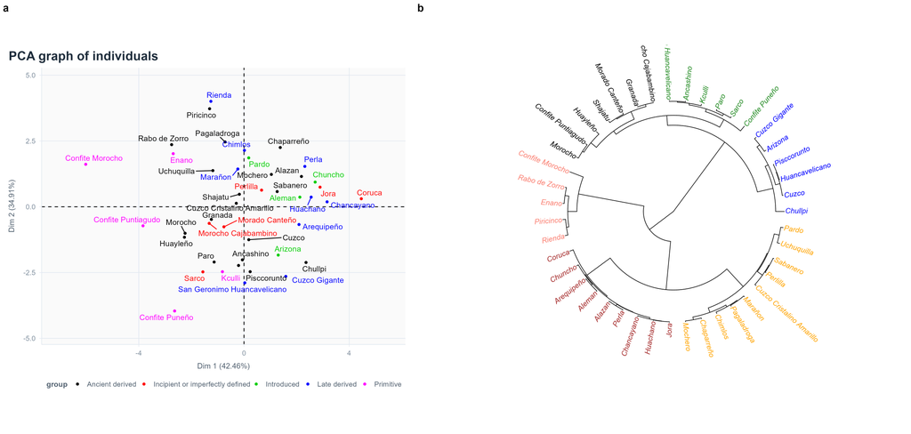

```r
hc <- cls$call$t$tree
k <- length(unique(cls$data.clust$clust))
clus <- cutree(hc, k)

colors <- c("salmon", "black", "forestgreen", "orange", "blue", "brown")

clsp_fan <- function() {

  plot(as.phylo(hc)
     , type = "fan"
     , tip.color = colors[clus]
     , label.offset = 0.01
     , cex = 0.8)
}

clsp <- \() {

  plot.HCPC(cls, choice = "map", draw.tree = F) # tree?

}

plot <- c(ind, clsp_fan) %>%
  plot_grid(plotlist = ., nrow = 1, labels = "auto"
            , rel_widths = c(1, 1.2)) %>%
  ggsave2("manuscript/Figure-3.jpg"
          , plot = .
          , width =42 , height = 20
          , units = "cm")

plot %>% include_graphics()
```

# 7 References

Broman, K. W., & Woo, K. H. (2017). Data organization in spreadsheets. The American Statistician, 72(1), 2–10. https://doi.org/10.1080/00031305.2017.1375989

Zuur, A. F., Ieno, E. N., & Elphick, C. S. (2009). A protocol for data exploration to avoid common statistical problems. Methods in Ecology and Evolution, 1(1), 3–14. https://doi.org/10.1111/j.2041-210x.2009.00001.x

Francoishusson. (2017, July 13). PCA course using FactoMineR | R-bloggers. R-bloggers. https://www.r-bloggers.com/2017/07/pca-course-using-factominer/

Kozak, M., & Piepho, H. (2017). What’s normal anyway? Residual plots are more telling than significance tests when checking ANOVA assumptions. Journal of Agronomy and Crop Science, 204(1), 86–98. https://doi.org/10.1111/jac.12220

Tanaka, E., & Hui, F. K. C. (2019). Symbolic formulae for linear mixed models. In Communications in computer and information science (pp. 3–21). https://doi.org/10.1007/978-981-15-1960-4_1

Schielzeth, H., Dingemanse, N. J., Nakagawa, S., Westneat, D. F., Allegue, H., Teplitsky, C., Réale, D., Dochtermann, N. A., Garamszegi, L. Z., & Araya‐Ajoy, Y. G. (2020). Robustness of linear mixed‐effects models to violations of distributional assumptions. Methods in Ecology and Evolution, 11(9), 1141–1152. https://doi.org/10.1111/2041-210x.13434